# Projet Licence

Sami bouzidi

21/09/2021

## 1. Objectif de l’étude

Ce projet a pour objectif de réaliser une analyse exploratoire approfondie et de développer des modèles statistiques explicatifs et prédictifs en utilisant un ensemble de données de notre choix. Les résultats de ces analyses et modèles permettront de répondre à des questions de recherche spécifiques et d’obtenir des informations utiles. L’idée principale de ce projet est de mettre en application ce que nous avons appris dans les UE STA101 : Analyse des données (méthodes descriptives), STA102 : Modèles linéaires et STA104 : Modèles linéaires.

### Méthodologie

Les étapes de la méthodologie comprennent :

1. **Prétraitement des Données** : Nous commencerons par charger, comprendre et nettoyer les données pour assurer leur qualité.
2. **Analyse Exploratoire des Données (EDA)** : Nous utiliserons des graphiques, des statistiques descriptives et des tests statistiques pour explorer les données, identifier les tendances et les relations entre les variables, et répondre aux questions de recherche.
3. **Modélisation statistique** : Nous développerons des modèles prédictifs, tels que des modèles linéaires ou d’autres algorithmes pertinents, pour répondre à nos questions de recherche. Nous comparerons ces modèles pour évaluer leur performance.
4. **Interprétation et Recommandations** : Nous interpréterons les résultats de manière approfondie et formulerons des recommandations basées sur notre analyse.

## 2. Présentation de la base de données

Les données proviennent du site Kaggle, une plateforme web qui organise des compétitions en science des données. Kaggle permet aux entreprises de proposer des problèmes en science des données et de récompenser les datalogistes obtenant les meilleures performances. Cette entreprise, fondée en 2010 par Anthony Goldbloom, est devenue un acteur majeur dans le domaine de la science des données (source : Wikipédia).

### Contexte

Le contexte de ces données est lié à la pandémie, qui a entraîné une perte d’emplois pour de nombreuses personnes. L’objectif de cet ensemble de données est d’améliorer la recherche d’emploi, en particulier pour ceux qui ont été touchés par la pandémie. Il contient plus de 3900 offres d’emploi pour des postes de data scientist.

### Structure de l’ensemble de données

**Lignes (Observations)** : Chaque ligne de l’ensemble de données représente une offre d’emploi spécifique. Les lignes sont les unités individuelles de données, et chaque ligne contient un ensemble d’informations associées à une offre d’emploi particulière.

**Colonnes (Variables)** : Les colonnes de l’ensemble de données représentent les différentes caractéristiques ou attributs associés à chaque offre d’emploi. Les colonnes comprennent des informations telles que l’estimation du salaire, l’emplacement, l’évaluation de l’entreprise, la description de l’emploi, et d’autres détails pertinents. Chaque colonne contient les valeurs correspondantes pour chaque offre d’emploi (chaque ligne).

## Étape 1 : Pré-traitement des données

Dans cette première partie du pré-traitement des données, nous effectuerons les opérations suivantes :

1. **Chargement des Données** : Nous importerons les données depuis la source Kaggle dans un format adapté pour l’analyse.
2. **Compréhension des Données** : Nous examinerons la structure de l’ensemble de données pour comprendre la nature de chaque colonne, les types de données, et identifier toutes données dupliquées, manquantes ou incohérentes.
3. **Transformation des Données** : Si nécessaire, nous effectuerons des transformations sur les données, telles que la normalisation ou la création de nouvelles variables, pour mieux répondre à nos objectifs de recherche.
4. **Nettoyage des Données** : Nous traiterons les données dupliquées, manquantes, les valeurs aberrantes (le cas échéant), et effectuerons d’autres ajustements nécessaires pour assurer la qualité des données.
5. **Préparation des Données** : Nous préparerons les données pour les étapes suivantes de l’analyse exploratoire et de la modélisation prédictive.

#### 1. **Chargement des librarie et des Données**

```r
# librairie utiliser

library(ggplot2)
library(stringr)
library("RColorBrewer")
library(corrplot)
library(car)          # Pour évaluer de façon visuelle, la linéarité entre deux variables
library(MASS)


library(gridExtra)
library(cluster)
library(factoextra)
library(fpc)
```

```r
data= read.csv("C:\\Users\\soso3\\Desktop\\Projet Licence\\DataScientist.csv\\DataScientist.csv", header=TRUE, sep=",",                              na.strings="-1")
```

#### 2. **Compréhension des Données**

```r
str(data)
```

```
## 'data.frame':    3909 obs. of  17 variables:
##  $ X                : int  0 1 2 3 4 5 6 7 8 9 ...
##  $ index            : int  0 1 2 3 4 5 6 7 8 9 ...
##  $ Job.Title        : chr  "Senior Data Scientist" "Data Scientist, Product Analytics" "Data Science Manager" "Data Analyst" ...
##  $ Salary.Estimate  : chr  "$111K-$181K (Glassdoor est.)" "$111K-$181K (Glassdoor est.)" "$111K-$181K (Glassdoor est.)" "$111K-$181K (Glassdoor est.)" ...
##  $ Job.Description  : chr  "ABOUT HOPPER\n\nAt Hopper, weâ\200\231re on a mission to make booking travel faster, easier, and more transpare"| __truncated__ "At Noom, we use scientifically proven methods to help our users create healthier lifestyles, and manage importa"| __truncated__ "Decode_M\n\…
##  $ Rating           : num  3.5 4.5 -1 3.4 3.4 2.9 4.4 -1 5 4.8 ...
##  $ Company.Name     : chr  "Hopper\n3.5" "Noom US\n4.5" "Decode_M" "Sapphire Digital\n3.4" ...
##  $ Location         : chr  "New York, NY" "New York, NY" "New York, NY" "Lyndhurst, NJ" ...
##  $ Headquarters     : chr  "Montreal, Canada" "New York, NY" "New York, NY" "Lyndhurst, NJ" ...
##  $ Size             : chr  "501 to 1000 employees" "1001 to 5000 employees" "1 to 50 employees" "201 to 500 employees" ...
##  $ Founded          : int  2007 2008 NA 2019 2007 1985 1993 NA 2018 2000 ...
##  $ Type.of.ownership: chr  "Company - Private" "Company - Private" "Unknown" "Company - Private" ...
##  $ Industry         : chr  "Travel Agencies" "Health, Beauty, & Fitness" NA "Internet" ...
##  $ Sector           : chr  "Travel & Tourism" "Consumer Services" NA "Information Technology" ...
##  $ Revenue          : chr  "Unknown / Non-Applicable" "Unknown / Non-Applicable" "Unknown / Non-Applicable" "Unknown / Non-Applicable" ...
##  $ Competitors      : chr  NA NA NA "Zocdoc, Healthgrades" ...
##  $ Easy.Apply       : chr  NA NA "True" NA ...
```

La structure de ce jeu de données est un dataframe contenant 3909 observations et 17 variables. La plupart de ces variables sont des chaînes de caractères, ce qui signifie qu’elles contiennent des informations textuelles. Cependant, pour effectuer des analyses et des modèles prédictifs, il est nécessaire de transformer ces variables en données quantitatives ou qualitatives, selon leur nature. Nous allons procéder de la maniere suivante:

**Transformation des Variables Chaînes de Caractères :** La première étape essentielle dans le prétraitement des données concerne la transformation des variables chaînes de caractères en un format adapté à notre objectif d’analyse. Cela inclut la création de nouvelles variables, la suppression de données inutiles, la division des chaînes de caractères pour obtenir des informations plus détaillées, et la conversion de données textuelles en catégories ou valeurs numériques. Nous allons traiter les variables suivantes

**Variable “Salary.Estimate” :** Nous allons commencer par cette variable car dans nos questionement futur elle representera une variable clé plus particulierement dans les modeles statistiques elle representera notre variable cible. La variable “Salary.Estimate” représente une plage d’estimation salariale annuelle pour une offre d’emploi. Pour la rendre plus lisible, nous effectuerons les actions suivantes :

- Suppression des lignes sans information salariale.
- Élimination de la mention “(Glassdoor est.)”.
- Création de nouvelles variables “Salaire_Min” et “Salaire_Max” dans le dataframe “data” pour représenter respectivement le salaire minimum et maximum.

```r
###################################################################################################
# "Salary.Estimate": Supprimer les lignes qui ne contiennent pas d'information sur le salaire annuel.
###################################################################################################

## à quoi ressemble ces lignes
cat( str_subset(data$ Salary.Estimate,"Per Hour") )
```

```
## $34-$53 Per Hour(Glassdoor est.) $34-$53 Per Hour(Glassdoor est.) $34-$53 Per Hour(Glassdoor est.) $34-$53 Per Hour(Glassdoor est.) $34-$53 Per Hour(Glassdoor est.) $34-$53 Per Hour(Glassdoor est.) $34-$53 Per Hour(Glassdoor est.) $10-$26 Per Hour(Glassdoor est.) $10-$26 Per Hour(Glassdoor est.) …
```

```r
# Nous indique sous forme de booleen si une ligne contient "Per Hour" ou  pas
pattern <- str_detect(data$ Salary.Estimate,"Per Hour")

# Suppression de ces lignes dans le dataframe data. On a conservé tous les TRUE en faisant la négation de pattern
data=data[!pattern,]


cat("verification des lignes supprimer: ", nrow(data))   # initialement 3909
```

```
## verification des lignes supprimer:  3888
```

```r
#########################################################################
#  "Salary.Estimate": Éliminer la mention "(Glassdoor est.) et $ et k".
#########################################################################

data$Salary.Estimate <- gsub("\\(Glassdoor est.\\)|\\$|K", "", data$Salary.Estimate)

# verification que "(Glassdoor est.)" et "$" et "k" sont bien supprimer
head(data$Salary.Estimate,3)
```

```
## [1] "111-181 " "111-181 " "111-181 "
```

```r
#####################################################################################
# "Salary.Estimate"Créer de nouvelles variables "Salaire_Min" et "Salaire_Max"
###############################################################################


# Divise la colonne 'Salary.Estimate' du dataframe 'data' en deux parties (min et max)
r=str_split(data$Salary.Estimate, "-", simplify = TRUE)

# Affiche les trois premières lignes de la matrice 'r' pour un échantillon des données
head(r,3)
```

```
##      [,1]  [,2]
## [1,] "111" "181 "
## [2,] "111" "181 "
## [3,] "111" "181 "
```

```r
# permet d'extraire que les valeurs numérique de 0 à 9 de la premiere colonne de 'r'
min=as.numeric(str_extract(r[,1], "[0-9]+"))
max=as.numeric(str_extract(r[,2], "[0-9]+"))

cat("On verifie les premières valeurs de la variable 'min': ", head(min), "\n" )
```

```
## On verifie les premières valeurs de la variable 'min':  111 111 111 111 111 111
```

```r
cat("On verifie les premières valeurs de la variable 'min' :", head(max) )
```

```
## On verifie les premières valeurs de la variable 'min' : 181 181 181 181 181 181
```

```r
data$estima_min=min        # nouvelle variable min dans le data.frame data
data$estima_max=max        # nouvelle variable max dans le data.frame data


# Cela crée une nouvelle colonne "Salaire_Aggrégé" contenant la moyenne de "Salaire_Min" et "Salaire_Max" pour chaque observation.
data$Salaire_Aggrégé <- rowMeans(data[c("estima_min", "estima_max")], na.rm = TRUE)
```

**Nous allons continuer avec d’autres variables qui peuvent nous interesser par la suite.**

```r
###########################################################
# 2. Diviser la variable "Location" en "Ville" et "Région"
#########################################################

 # délimateur par une virgule
b <- str_split(data$Location, ",", simplify = TRUE)

# Crée la variable "lieu_ville" à partir de la première colonne de la matrice b
data$lieu_ville <- b[, 1]

# Crée la variable "lieu_region" à partir de la deuxième colonne de la matrice b
data$lieu_region <- b[, 2]



##########################
# la variable Company.Name
##########################

#  Supprimer la partie "\n..." de la variable "Company.Name" en utilisant gsub
data$Company.Name <- gsub("[\n][0-9]+[.][0-9]+", "", data$Company.Name)



##########################
# la variable Easy.Apply
##########################

# Remplacer "NA" par "Unkn" et "True" par "Easy" dans la variable "Easy.Apply" en utilisant str_replace_all
data$Easy.Apply <- str_replace_all(data$Easy.Apply, c( "True" = "Easy"))



# Vérifier les dimensions actuelles du dataframe "data" (nombre de lignes et de colonnes)

cat(names(data), "nom des colonnes", "\n")
```

```
## X index Job.Title Salary.Estimate Job.Description Rating Company.Name Location Headquarters Size Founded Type.of.ownership Industry Sector Revenue Competitors Easy.Apply estima_min estima_max Salaire_Aggrégé lieu_ville lieu_region nom des colonnes
```

```r
cat(nrow(data), "nbres de lignes")
```

```
## 3888 nbres de lignes
```

**Élimination des Colonnes inutiles**

```r
data[ c("X","index" ,"Salary.Estimate", "Job.Description", "Company.Name", "Location", "Headquarters", "Competitors", "Founded", "Industry", "estima_min", "estima_max","lieu_ville" ) ]= NULL

cat("dimension du nouveau data: ")
```

```
## dimension du nouveau data:
```

```r
cat(dim(data), "\n\n")
```

```
## 3888 9
```

```r
colnames(data)
```

```
## [1] "Job.Title"         "Rating"            "Size"
## [4] "Type.of.ownership" "Sector"            "Revenue"
## [7] "Easy.Apply"        "Salaire_Aggrégé"   "lieu_region"
```

**Transformation des Variables Catégorielles**

```r
# Sélectionner les noms des colonnes contenant des données de type caractère (chaînes de caractères)
chr_column_names <- colnames(data)[sapply(data, is.character)]


# Conversion des colonnes caractère en facteurs
for (var in chr_column_names) {
  data[[var]] <- as.factor(data[[var]])
}

# Définir l'ordre des niveaux pour les variables Size et Revenue
data$Size <- factor(data$Size, levels = c("1 to 50 employees", "51 to 200 employees", "201 to 500 employees",
                                          "501 to 1000 employees", "1001 to 5000 employees", "5001 to 10000 employees",
                                          "10000+ employees", "Unknown"), ordered = TRUE)

data$Revenue <- factor(data$Revenue, levels = c("Less than $1 million (USD)", "$1 to $5 million (USD)",
                                                "$5 to $10 million (USD)", "$10 to $25 million (USD)",
                                                "$25 to $50 million (USD)", "$50 to $100 million (USD)",
                                                "$100 to $500 million (USD)", "$500 million to $1 billion (USD)",
                                                "$1 to $2 billion (USD)", "$2 to $5 billion (USD)",
                                                "$5 to $10 billion (USD)", "$10+ billion (USD)",
                                                "Unknown / Non-Applicable"), ordered = TRUE)


# On change les noms des poste

colnames(data)= c("nom_poste", "eval_entrep", "taille_entrep", "Type_propriete", "secteur", "revenue_entrep","Easy.Apply",  "Salaire_Aggrégé", "lieu_region" )

# On verifie qu'on a bien changé les classes en facteur et changé les nom des postes
str(data)
```

```
## 'data.frame':    3888 obs. of  9 variables:
##  $ nom_poste      : Factor w/ 2065 levels "#104733 HPC Systems and Data Engineer",..: 1687 816 633 361 888 652 1425 1420 34 1425 ...
##  $ eval_entrep    : num  3.5 4.5 -1 3.4 3.4 2.9 4.4 -1 5 4.8 ...
##  $ taille_entrep  : Ord.factor w/ 8 levels "1 to 50 employees"<..: 4 5 1 3 2 3 2 1 1 4 ...
##  $ Type_propriete : Factor w/ 14 levels "College / University",..: 2 2 14 2 2 2 2 14 2 2 ...
##  $ secteur        : Factor w/ 25 levels "Accounting & Legal",..: 25 8 NA 13 6 14 10 NA 13 10 ...
##  $ revenue_entrep : Ord.factor w/ 13 levels "Less than $1 million (USD)"<..: 13 13 13 13 13 13 13 13 13 13 ...
##  $ Easy.Apply     : Factor w/ 1 level "Easy": NA NA 1 NA NA NA NA 1 1 NA ...
##  $ Salaire_Aggrégé: num  146 146 146 146 146 146 146 146 146 146 ...
##  $ lieu_region    : Factor w/ 11 levels " AZ"," CA"," DE",..: 7 7 7 6 7 7 7 7 7 7 ...
```

#### 4. **Nettoyage des Données**

**Gestion des données manquantes**

```r
# Remplacement des valeurs -1 par NA dans la variable "Rating"
data[data[, 2] == -1, 2] = NA

# Nombre de lignes complètes sans NA
complete_cases_count <- sum(complete.cases(data))
cat("Nombre de lignes complètes sans données manquantes : ", complete_cases_count, "\n\n")
```

```
## Nombre de lignes complètes sans données manquantes :  161
```

```r
# Nombre de lignes contenant des NA
na_cases_count <- sum(!complete.cases(data))
cat("Nombre de lignes contenant des données manquantes : ", na_cases_count, "\n\n")
```

```
## Nombre de lignes contenant des données manquantes :  3727
```

```r
# Proportion des données complètes dans le jeu de données (en pourcentage)
complete_cases_percent <- (complete_cases_count / nrow(data)) * 100
cat("Proportion des données complètes dans le jeu de données : ", complete_cases_percent, "%\n\n")
```

```
## Proportion des données complètes dans le jeu de données :  4.140947 %
```

```r
# Proportion des données manquantes dans le jeu de données (en pourcentage)
na_cases_percent <- (na_cases_count / nrow(data)) * 100
cat("Proportion des données manquantes dans le jeu de données : ", na_cases_percent, "%\n\n")
```

```
## Proportion des données manquantes dans le jeu de données :  95.85905 %
```

```r
# Nombre de valeurs manquantes pour chaque variable
print("Nombre de valeurs manquantes pour chaque variable :")
```

```
## [1] "Nombre de valeurs manquantes pour chaque variable :"
```

```r
apply(data, MARGIN = 2, function(x) sum(is.na(x)))
```

```
##       nom_poste     eval_entrep   taille_entrep  Type_propriete         secteur
##               0             405             229             229             543
##  revenue_entrep      Easy.Apply Salaire_Aggrégé     lieu_region
##             229            3725               0               0
```

```r
cat("\n")
```

[output not shown]

[output not shown]

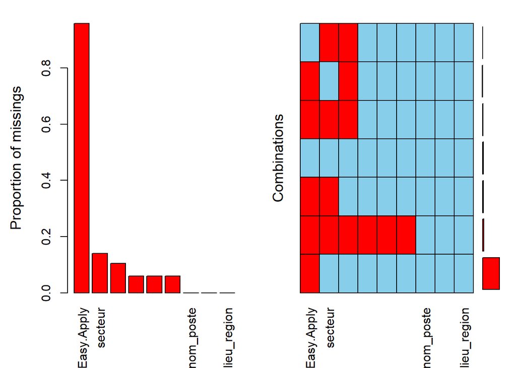

Avant d’analyser la situation des données manquantes dans ce dataset, rappelons les différents types de données manquantes :

**1. Données Manquantes Complètement au Hasard (MCAR - Missing Completely at Random) :** Dans ce scénario, la probabilité qu’une valeur soit manquante ne dépend d’aucune autre variable du jeu de données. Cela signifie que les valeurs manquantes sont le résultat du pur hasard, sans relation avec d’autres variables observées ou non observées.

**2. Données Manquantes au Hasard (MAR - Missing at Random) :** Les données manquantes de ce type dépendent d’autres variables observées dans le jeu de données. La probabilité qu’une valeur soit manquante dépend des valeurs d’autres variables, mais pas de la propre valeur manquante.

**3. Données Manquantes Systématiques (MNAR - Missing Not at Random) :** Dans ce cas, la probabilité qu’une valeur soit manquante est liée à la propre valeur manquante. Les valeurs manquantes sont influencées par des facteurs non observés ou non enregistrés et peuvent être biaisées.

En examinant notre dataset, nous constatons que 95,86 % des données sont manquantes, laissant seulement 4,14 % de données disponibles. Cette situation révèle une qualité de jeu de données plutôt médiocre, étant donné que le nombre de lignes incomplètes dépasse largement celui des lignes complètes.

Les données manquantes semblent être réparties de manière aléatoire (MCAR ou MAR) sur plusieurs variables. Prenons l’exemple de la variable “Easy.Apply” : elle affiche un taux élevé de valeurs manquantes, atteignant 95,81 %. Les raisons de ces valeurs manquantes sont variées, allant du fait que certaines offres d’emploi ne permettent pas une candidature facile via Easy Apply à l’indisponibilité de ces informations lors de la collecte des données. Cette variabilité des raisons de données manquantes peut être considérée comme aléatoire, car la probabilité de données manquantes dépend de facteurs observables ou non.

De plus, d’autres variables telles que “eval_entrep,” “taille_entrep,” “Type_propriété,” “industrie,” “secteur,” et “revenue_entrep” présentent également des taux de valeurs manquantes. Les raisons de ces valeurs manquantes peuvent être attribuées aux offres d’emploi elles-mêmes et à la manière dont elles ont été collectées. Par exemple, certaines entreprises peuvent choisir de ne pas fournir ces informations lors de la publication de leurs offres. Ces valeurs manquantes semblent également aléatoires, car elles ne semblent pas être liées à des facteurs non observés.

Il est crucial de souligner l’importance du traitement des valeurs manquantes, car elles peuvent compromettre la qualité des analyses ultérieures. Différentes méthodes d’imputation de données, telles que l’utilisation de l’algorithme AFMD pour les données MAR, peuvent être envisagées pour conserver un maximum d’informations tout en minimisant les biais. Cependant, dans notre cas, nous avons opté pour une solution concise en supprimant les lignes contenant des valeurs manquantes, compte tenu de la proportion élevée de données manquantes dans certaines variables. Cette approche permet de simplifier l’analyse tout en conservant l’intégrité du jeu de données restant.

**Suppression des Valeurs Manquantes**

```r
# Suppression de la variable "Easy.Apply"
data$Easy.Apply <- NULL

# on supprime les valeurs manquantes en fonction de la variable secteur et de eval_entrep
data <- subset(data, !is.na(data$secteur))
data <- subset(data, !is.na(data$eval_entrep))

cat("verification du nombre de valeurs manquantes (NA) dans chaque colonne du dataframe: ", "\n")
```

```
## verification du nombre de valeurs manquantes (NA) dans chaque colonne du dataframe:
```

```r
sapply(data,function(x) sum(is.na(x)))
```

```
##       nom_poste     eval_entrep   taille_entrep  Type_propriete         secteur
##               0               0               0               0               0
##  revenue_entrep Salaire_Aggrégé     lieu_region
##               0               0               0
```

```r
cat("\n")
```

```r
str(data)
```

```
## 'data.frame':    3282 obs. of  8 variables:
##  $ nom_poste      : Factor w/ 2065 levels "#104733 HPC Systems and Data Engineer",..: 1687 816 361 888 652 1425 34 1425 652 838 ...
##  $ eval_entrep    : num  3.5 4.5 3.4 3.4 2.9 4.4 5 4.8 3.9 4.4 ...
##  $ taille_entrep  : Ord.factor w/ 8 levels "1 to 50 employees"<..: 4 5 3 2 3 2 1 4 3 2 ...
##  $ Type_propriete : Factor w/ 14 levels "College / University",..: 2 2 2 2 2 2 2 2 2 2 ...
##  $ secteur        : Factor w/ 25 levels "Accounting & Legal",..: 25 8 13 6 14 10 13 10 13 13 ...
##  $ revenue_entrep : Ord.factor w/ 13 levels "Less than $1 million (USD)"<..: 13 13 13 13 13 13 13 13 13 7 ...
##  $ Salaire_Aggrégé: num  146 146 146 146 146 146 146 146 146 146 ...
##  $ lieu_region    : Factor w/ 11 levels " AZ"," CA"," DE",..: 7 7 6 7 7 7 7 7 7 7 ...
```

**Identification des doublons**

```r
doublonstest<-which(duplicated(data))   ##  affichent les lignes admettant des doublons.
doublonstest
```

```
## [1] 2143 2157 2160 2364
```

```r
 # suppression des doublons
data= data[-doublonstest, ]
```

#### 5. **Préparation des Données**

L’objectif ici est de préparer nos données pour la modélisation en posant des questions sur chaque variable du jeu de données. Étant donné que la plupart de nos variables sont qualitatives, nous avons élaboré une fonction appelée plot_meilleurs_variable. Cette fonction génère des graphiques en camembert (pie charts) pour montrer les catégories les plus fréquentes des variables qualitatives.

```r
plot_meilleurs_variable <- function(data, variable_quali, nbre) {
  # Cette fonction crée un pie chart pour visualiser les effectifs des catégories d'une variable qualitative.

  # Arguments :
  # - data : le jeu de données
  # - variable_quali : la variable qualitative à analyser
  # - nbre : le nombre de catégories les plus fréquentes à afficher

  # Identifier les effectifs de chaque catégorie de la variable qualitative
  resume <- aggregate(data[[variable_quali]], by = list(data[[variable_quali]]), FUN = length)
  colnames(resume) <- c(variable_quali, "nombre")

  # Trier les catégories par nombre d'effectifs décroissant
  resume <- resume[order(resume$nombre, decreasing = TRUE), ]

  # Extraire les "nbre" catégories les plus fréquentes
  top <- head(resume, nbre)

  # Créer un pie chart avec les "nbre" catégories les plus fréquentes et leurs effectifs
  labels_with_space <- paste(top[[variable_quali]], "\n Nombre : ", top$nombre)
  title <- paste("Catégories les plus fréquentes de", variable_quali)
  pie(top$nombre, labels = labels_with_space, col = brewer.pal(n = nbre, name = "RdBu"), main = title)
}
```

1.1- Combien contient de modalités la variable nom_poste?

```r
nlevels(data$nom_poste)
```

```
## [1] 2065
```

1.2- Quelles sont les 6 emplois les plus demandéés?

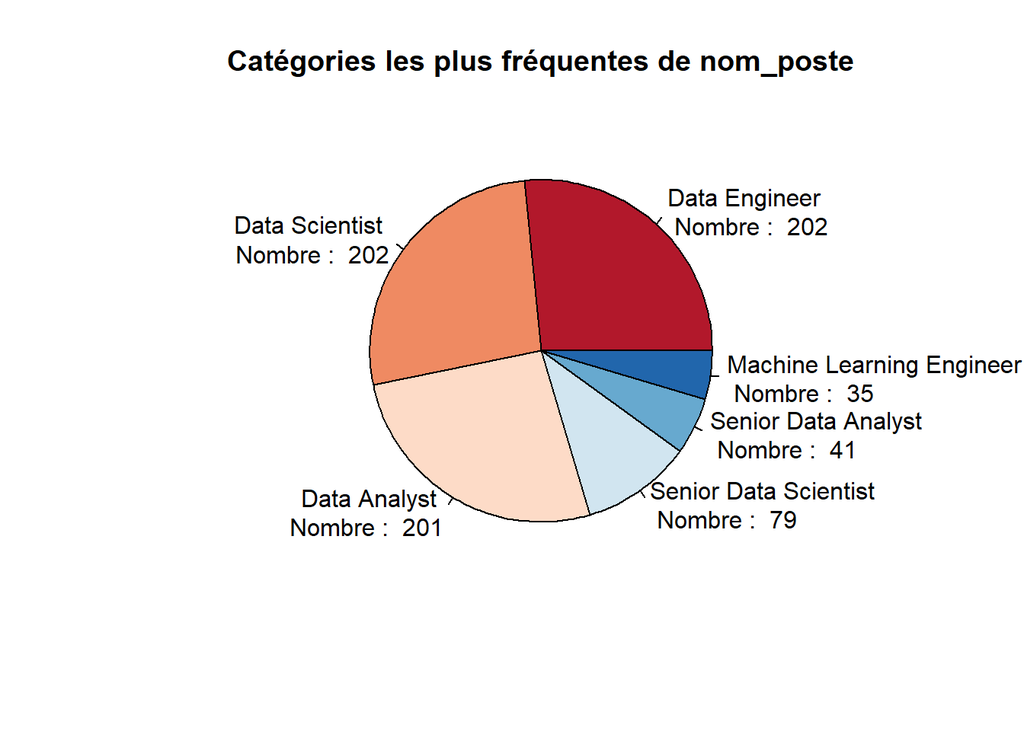

```r
plot_meilleurs_variable(data, "nom_poste", 6)
```

1.bis- Quelles sont les 8 emplois les mieux évalués

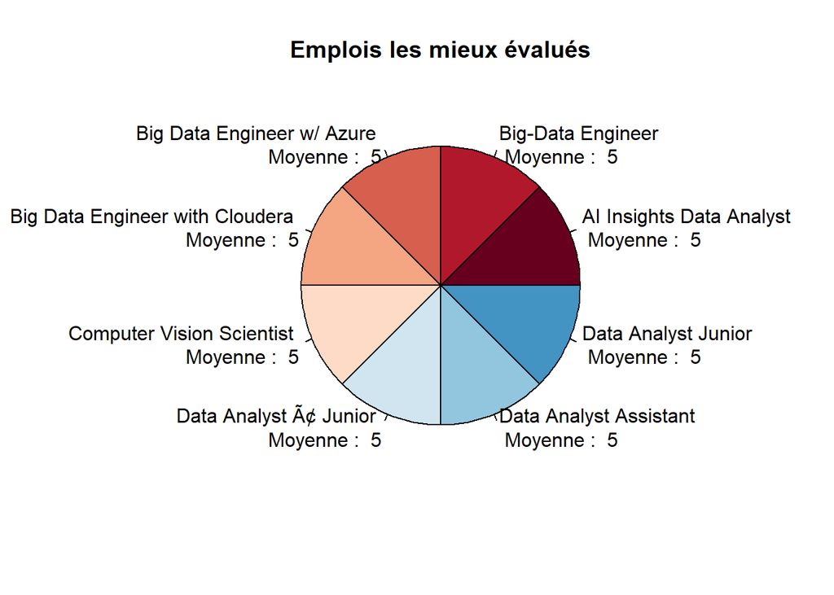

```r
# Identifier les emplois les mieux évalués
emplois_mieux_evalues <- aggregate(data$eval_entrep, by = list(data$nom_poste), FUN = mean)
colnames(emplois_mieux_evalues) <- c("nom_poste", "eval_moyenne")
emplois_mieux_evalues <- emplois_mieux_evalues[order(emplois_mieux_evalues$eval_moyenne, decreasing = TRUE), ]

# Extraire les 10 emplois les mieux évalués
top_10_mieux_evalues <- head(emplois_mieux_evalues, 8)

# Créer un pie chart avec les 10 emplois les mieux évalués et leurs moyennes
labels_with_space <- paste(top_10_mieux_evalues$nom_poste, "\n Moyenne : ", round(top_10_mieux_evalues$eval_moyenne, 2))
pie(top_10_mieux_evalues$eval_moyenne, labels = labels_with_space, col = brewer.pal(n = 10, name = "RdBu"), main = "Emplois les mieux évalués")
```

2.1- Combien contient de modalités la variable secteurs d’activité?

```r
nlevels(data$secteur)
```

```
## [1] 25
```

2.2- Quelles sont les 6 secteurs d’activités les plus rechercher?

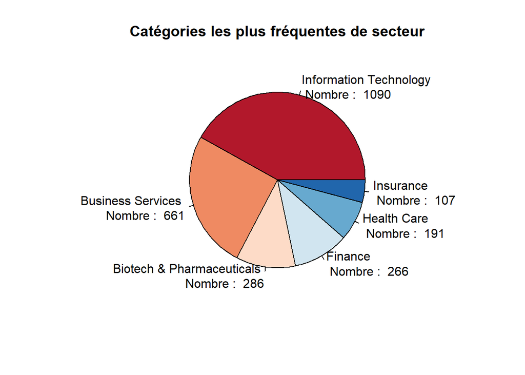

```r
plot_meilleurs_variable(data, "secteur", 6)
```

3.1- Combien contient de modalités la variable revenue_entrep?

```r
nlevels(data$revenue_entrep)
```

```
## [1] 13
```

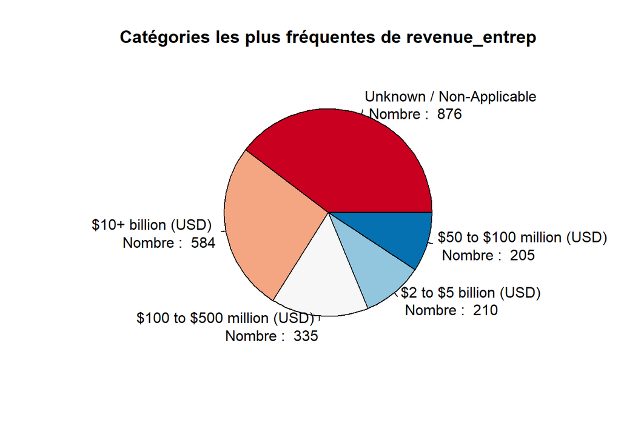

```r
plot_meilleurs_variable(data, "revenue_entrep", 5)
```

4.1- Combien contient de modalités la variable lieu_region?

```r
nlevels(data$lieu_region)
```

```
## [1] 11
```

4.2- Quelles sont les 6 régions qui contient le plus d’offre d’emplois ?

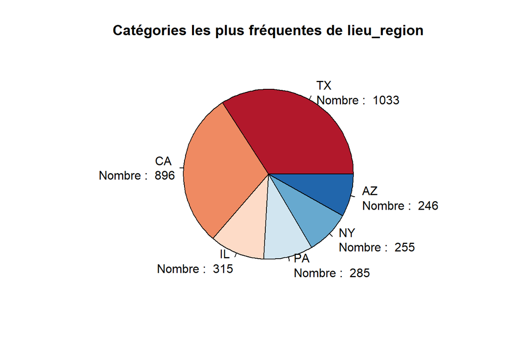

```r
plot_meilleurs_variable(data, "lieu_region", 6)
```

5.1- Combien contient de modalité la variable Type_propriete?

```r
nlevels(data$Type_propriete)
```

```
## [1] 14
```

5.2- Quelle type de propriété offre le plus d’emplois?

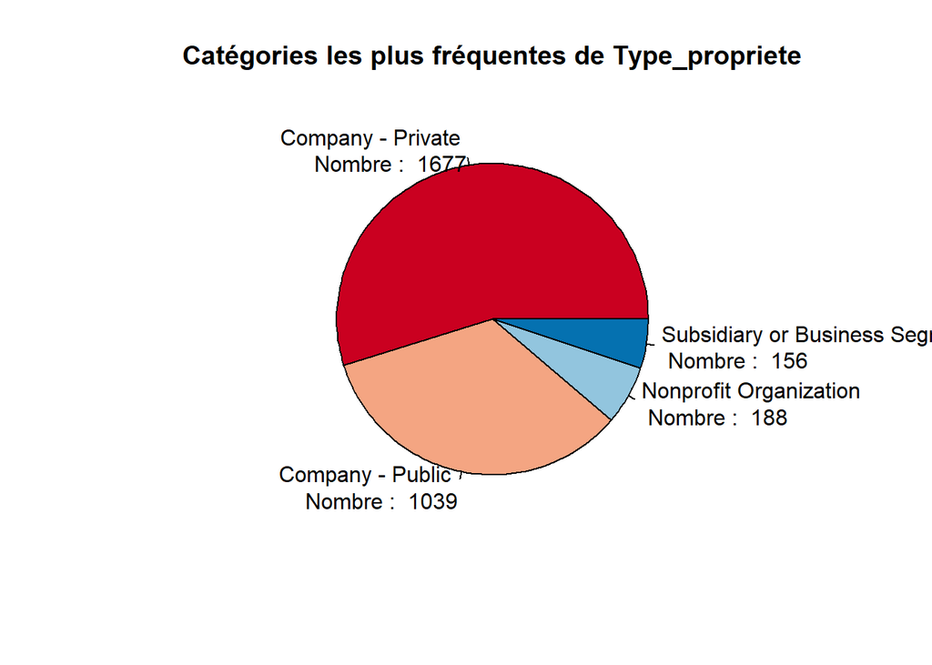

```r
plot_meilleurs_variable(data, "Type_propriete", 4)
```

6.1- Combien contient de modalités la variable taille_entrep?

```r
nlevels(data$taille_entrep)
```

```
## [1] 8
```

6.2- Quelles sont les tailles d’entreprise qui recrutent le plus?

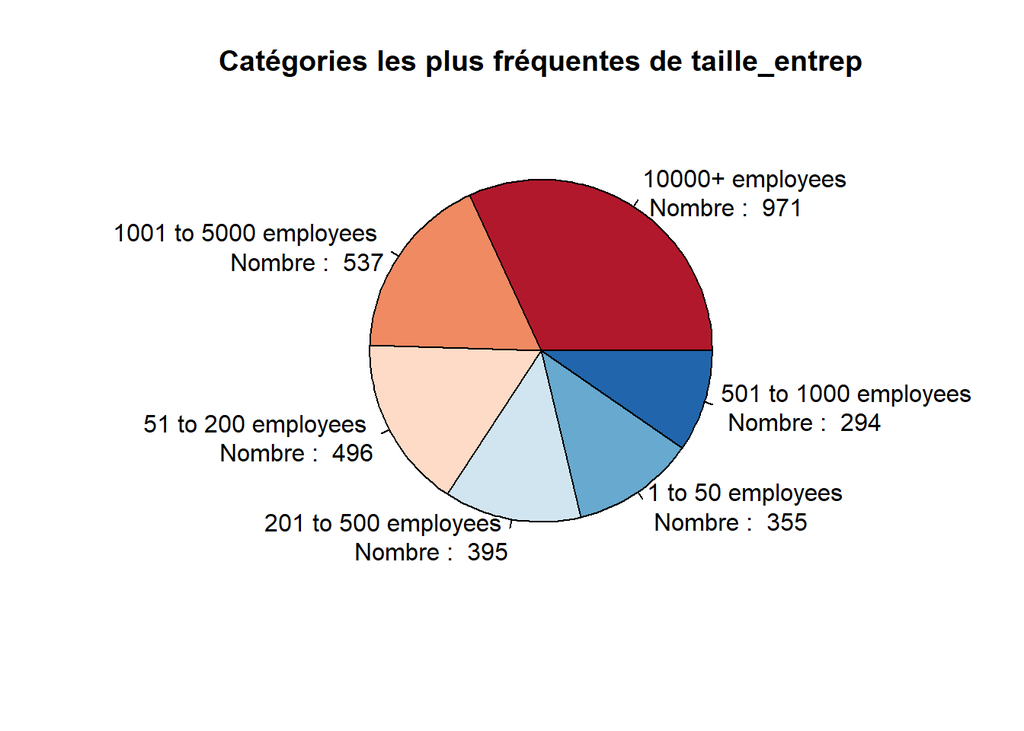

```r
plot_meilleurs_variable(data, "taille_entrep", 6)
```

A Travers ces questions de type univariée nous avons vu que la majorité des variables qualitatives poseront problèmes pour diverse raison que nous expliquons dans le point suivant.

**Gestion des Variables Qualitatives**

Lorsqu’il s’agit d’analyser des données, les variables qualitatives, également connues sous le nom de catégorielles, jouent un rôle crucial. Cependant, elles peuvent poser divers défis à l’analyse en raison de certains problèmes courants. Dans cette section, nous explorons ces problèmes et discutons de nos approches pour les résoudre.

**Problèmes Courants des Variables Qualitatives :**

- Modalités Rares : Lorsqu’une variable qualitative présente des catégories avec un faible nombre d’observations, cela peut entraîner une instabilité dans les résultats, rendant difficile leur interprétation.
- Nombre Élevé de Modalités : Une variable qualitative avec un grand nombre de modalités peut compliquer les modèles prédictifs en augmentant la dimension de l’espace des caractéristiques, entraînant du surajustement et des temps de calcul plus longs.
- Différences de Fréquence : Si une variable qualitative présente des différences importantes de fréquence entre ses modalités, cela peut affecter la capacité du modèle à prédire correctement les catégories moins fréquentes.

Dans notre ensemble de données, la plupart des variables qualitatives sont confrontées à ces problèmes. Il est important de noter que certaines modalités peuvent présenter à la fois un nombre élevé de modalités et des modalités rares, créant ainsi des différences de fréquence au sein de la variable.

**Notre Approche :**

Pour résoudre ces problèmes, nous envisageons d’utiliser deux approches principales :

1. **Agrégation Manuelle :** Pour les variables qualitatives où cela est nécessaire, nous effectuerons une agrégation manuelle des modalités similaires. Cette approche nous permettra de simplifier l’analyse tout en préservant les informations essentielles. Le choix d’agréger des modalités sera basé sur des critères tels que la rareté et la similarité.
2. **Classification Ascendante Hiérarchique (CAH) :** Dans le cas de variables qualitatives plus complexes avec un grand nombre de modalités, nous utiliserons la CAH. Cette technique nous permettra de regrouper automatiquement des modalités similaires en clusters, réduisant ainsi la dimension tout en maintenant la signification des données. Le nombre de clusters sera déterminé à l’aide de méthodes telles que la Méthode Silhouette, la Méthode Elbow et la Méthode Gap Statistic. Enfin, nous évaluerons les clusters formés pour garantir leur qualité à l’aide de mesures de validation interne.

**Les Mesures de Validation Interne Utilisées Sont Les Suivantes :**

- **Indice de Dunn :** Cette mesure évalue la qualité des clusters en termes de séparation et de compacité. Un Indice de Dunn élevé signifie que les clusters sont bien séparés et compacts, ce qui peut être bénéfique pour la prédiction. Il nous aide à sélectionner une configuration de clusters qui améliore potentiellement les performances de nos modèles prédictifs. Un Indice de Dunn élevé indique une meilleure qualité de clustering.
- **Entropie :** L’entropie nous permet de vérifier la pureté des clusters. Elle indique si les clusters sont homogènes en termes de classes. Des clusters homogènes en termes de classes peuvent faciliter la prédiction.
- **Moyenne au Sein des Clusters :** Cette mesure nous donne une idée de la compacité à l’intérieur des clusters. Des clusters compacts peuvent signifier que les données à l’intérieur de chaque cluster sont similaires, ce qui peut être utile pour construire des modèles précis.

En utilisant ces mesures de validation interne, nous pouvons évaluer la qualité des clusters formés lors de l’agrégation de modalités. Cette évaluation est essentielle pour garantir que les clusters résultants sont significatifs et qu’ils faciliteront la construction de modèles prédictifs fiables.

**Voici les étapes de gestion des variables qualitatives :**

1. **Examen Initial :** Nous commençons par examiner chaque variable qualitative une par une à l’aide de la fonction `generate_frequency_table`. Cette étape nous permet d’identifier des problèmes potentiels, tels que des modalités rares, un grand nombre de modalités ou des différences de fréquence significatives.
2. **Nettoyage Initial :** Si la fonction `generate_frequency_table` révèle des problèmes, nous utilisons la fonction `nettoyer_variable` pour nettoyer la variable. Cela comprend la suppression de niveaux indésirables et des valeurs manquantes.
3. **Choix de l’Approche de Gestion :** En fonction de la complexité de la variable qualitative et des problèmes identifiés, nous décidons si une agrégation manuelle ou automatique est nécessaire.

En résumer l’agrégation de modalités et la gestion efficace des variables qualitatives sont des étapes essentielles pour obtenir des analyses de données robustes. En utilisant ces approches, nous simplifierons notre analyse, améliorerons nos modèles prédictifs et obtiendrons des résultats plus fiables.

**Fonction de Table de Fréquence pour Variable Qualitative**

```r
generate_frequency_table <- function(data, qualitative_variable) {

  # Utiliser table() pour compter les occurrences des modalités
  table_result <- table(data[[qualitative_variable]])

  # Utiliser prop.table() pour obtenir les fréquences relatives
  freq_relatives <- round(prop.table(table_result), 3)

  # Créer un dataframe avec les effectifs et les fréquences relatives
  result_dataframe <- data.frame(
    Modalite = names(table_result),
    Effectif = as.vector(table_result),
    Frequence = as.vector(freq_relatives)
  )

  # Trier le dataframe par fréquences relatives décroissantes
  result_dataframe <- result_dataframe[order(result_dataframe$Frequence, decreasing = TRUE), ]

  return(result_dataframe)
}
```

**Fonction de Nettoyage de Variable Qualitative**

```r
nettoyer_variable <- function(data, variable, niveaux_a_supprimer = NULL) {
  # Supprimer les niveaux indésirables
  if (!is.null(niveaux_a_supprimer)) {
    data[[variable]] <- droplevels(data[[variable]], exclude = niveaux_a_supprimer)
  }

  # Supprimer les lignes avec des valeurs manquantes dans la variable
  data <- data[!is.na(data[[variable]]), ]

  return(data)
}
```

##### **Les fonctions pour mettre en place le CAH**

**Fonction pour calculer la matrice de dissimilarité basée sur l’indice de Dice**

```r
# Fonction pour calculer la matrice de dissimilarité basée sur l'indice de Dice

calculate_dice_similarity_matrix <- function(data, variable_name) {
  # Étape 1 : Sélectionnez la variable catégorielle à partir des données
  variable <- data[[variable_name]]

  # Étape 2 : Transformez la variable en encodage one-hot
  encoded_data <- model.matrix(~ variable - 1, data = data)

  # Étape 3 : Calculez la matrice de dissimilarité (indice de Dice)
  # Créez une matrice vide de la même taille que les données encodées
  similarity_matrix <- matrix(0, ncol(encoded_data), ncol(encoded_data))

  # Nommez les lignes et colonnes de la matrice avec les noms des variables
  rownames(similarity_matrix) <- colnames(similarity_matrix) <- colnames(encoded_data)

  # Parcourez toutes les paires de variables encodées
  for (i in 1:(ncol(encoded_data) - 1)) {
    for (j in (i + 1):ncol(encoded_data)) {
      # Calculez l'indice de Dice entre les deux variables
      similarity_matrix[i, j] <- similarity_matrix[j, i] <-
        0.5 * sum((encoded_data[, i] - encoded_data[, j])^2)
    }
  }

  # Étape 4 : Transformez la matrice de similarité en matrice de distance
  distance_matrix <- as.dist(sqrt(similarity_matrix))  # Ajout de la parenthèse autour de sqrt


  # Étape 5 : Renvoyez la matrice de distance
  return(distance_matrix)
}
```

**Fonction choix du nombre de cluster**

```r
# Fonction pour afficher le graphique d'inertie
afficher_graphique_inertie <- function(data, variable) {
  distance_matrix <- calculate_dice_similarity_matrix(data, variable)
  arbre.moda <- hclust(distance_matrix, method = "average")

  # Sous-graphique 1 : Inertie
  inertie <- sort(arbre.moda$height, decreasing = TRUE)
  plot(inertie[1:length(inertie)], type = "s", xlab = "Nombre de classes", ylab = "Inertie", main = "Inertie")
}



# Fonction pour organiser les graphiques
# Fonction pour organiser les graphiques
organiser_graphiques <- function(data, variable) {
  distance_matrix <- calculate_dice_similarity_matrix(data, variable)
  matrice_sim <- as.matrix(distance_matrix)

  # Obtenez le nombre de niveaux de la variable spécifiée
  k_max <- nlevels(data[[variable]]) - 1

  # Sous-graphique 2 : Méthode Silhouette
  optimal_clusters_silhouette <- fviz_nbclust(matrice_sim, FUNcluster = hcut, method = "silhouette", hc_method = "average",
                                               k.max = k_max)
  plot2 <- optimal_clusters_silhouette + labs(subtitle = "Silhouette method")

  # Sous-graphique 3 : Méthode Elbow
  optimal_clusters_elbow <- fviz_nbclust(matrice_sim, FUNcluster = hcut, method = "wss", hc_method = "average",
                                         k.max = k_max)
  plot3 <- optimal_clusters_elbow + geom_vline(xintercept = 4, linetype = 2) + labs(subtitle = "Elbow method")

  # Sous-graphique 4 : Méthode Gap Statistic
  optimal_clusters_gap_stat <- fviz_nbclust(matrice_sim, FUNcluster = hcut, method = "gap_stat", nboot = 600,
                                            hc_method = "average", k.max = k_max)
  plot4 <- optimal_clusters_gap_stat + labs(subtitle = "Gap statistic method")

  # Organiser les sous-graphiques en une seule disposition
  grid.arrange(plot2, plot3, plot4, ncol = 1)
}
```

**Validation interne**

```r
generer_resultats_clustering <- function(data, variable, nbre_choix) {
  # Calculer la matrice de similarité
  distance_matrix <- calculate_dice_similarity_matrix(data, variable)

  # Créer une liste vide pour stocker les résultats
  result_list <- list()

  # Créer une deuxième liste vide pour stocker uniquement les stats avec des noms
  stats_list <- list()

  # Liste pour stocker les attributs de clustering
  cluster_list <- list()


  for (ap in nbre_choix) {
    # Créer une partition en clusters de test
    arbre.moda <- hclust(distance_matrix, method = "average")
    clustering <- cutree(arbre.moda, k = ap)

    # Calculer les statistiques de validation de clustering
    stats <- cluster.stats(distance_matrix, clustering)

    # Créez une sous-liste avec des noms
    sub_list <- list(nbre_choix = ap, stats = stats, clustering = clustering)  # Inclure les attributs de clustering

    # Ajoutez la sous-liste aux listes respectives
    result_list[[length(result_list) + 1]] <- sub_list
    stats_list[[length(stats_list) + 1]] <- sub_list$stats
    cluster_list[[length(cluster_list) + 1]] <- sub_list$clustering
  }

  # Créez une matrice vide pour stocker les résultats
  elements <- c( "average.within", "dunn", "dunn2", "entropy")
  results_matrix <- matrix(nrow = length(elements), ncol = length(stats_list))

  # Définir les noms des lignes de la matrice
  rownames(results_matrix) <- elements

  # Définir les noms de colonnes en utilisant les valeurs de nbre_choix avec "cluster_"
  colnames(results_matrix) <- paste("cluster_", as.character(nbre_choix), sep = " ")

  for (j in 1:length(stats_list)) {
    stats <- stats_list[[j]]  # Obtenez les statistiques de la liste
    for (i in 1:length(elements)) {
      result <- stats[[elements[i]]]
      results_matrix[i, j] <- result
    }
  }

  return(list(result_list = result_list, stats_list = stats_list, cluster_list = cluster_list, results_matrix = results_matrix))
}
```

##### **Pour la variable lieu_region**

```r
frequency_table <- generate_frequency_table(data, "lieu_region")
print(frequency_table)
```

```
##           Modalite Effectif Frequence
## 10              TX     1033     0.315
## 2               CA      896     0.273
## 5               IL      315     0.096
## 9               PA      285     0.087
## 7               NY      255     0.078
## 1               AZ      246     0.075
## 8               OH      153     0.047
## 4               FL       55     0.017
## 6               NJ       27     0.008
## 3               DE        9     0.003
## 11  United Kingdom        4     0.001
```

Ici on voit clairement la modalité United Kingdom ne sert a rien nous allons la supprimer. D’autant plus nous voulons travailler que sur les etats americains

```r
# Utilisation de la fonction pour nettoyer la variable taille_entrep
data <- nettoyer_variable(data, "lieu_region", niveaux_a_supprimer = " United Kingdom")


# Verification
cat( "le nombre de region maintenant :", nlevels(data$lieu_region) )    # 3345 obs initial
```

```
## le nombre de region maintenant : 10
```

```r
cat( "le nombre de ligne maintenant :", nrow(data) )
```

```
## le nombre de ligne maintenant : 3274
```

Pour cette variable nous ferons une agrégation manuelle, nous rassemblerons les États en fonction des régions géographiques. Voici comment nous allons procéder :

Cette approche nous permettra de gérer les modalités rares et similaires de manière plus efficace.

```r
# Changez les modalités
levels(data$lieu_region)[levels(data$lieu_region) %in% c(" AZ", " TX")] <- "sud_Ouest"
levels(data$lieu_region)[levels(data$lieu_region) %in% c(" CA")]       <- "cote_Ouest"
levels(data$lieu_region)[levels(data$lieu_region) %in% c(" DE", " FL", " NJ"," NY", " PA")] <- "cote_est"
levels(data$lieu_region)[levels(data$lieu_region) %in% c(" IL", " OH")] <- "Sud_Ouest"

# Vérifiez les niveaux mis à jour

cat("On verifie les nouvelles modalites :")
```

```
## On verifie les nouvelles modalites :
```

```r
cat(levels(data$lieu_region))
```

```
## sud_Ouest cote_Ouest cote_est Sud_Ouest
```

```r
cat("dimension du data :", dim(data) )
```

```
## dimension du data : 3274 8
```

##### **Pour la variable “taille_entrep”**

```r
frequency_table <- generate_frequency_table(data, "taille_entrep")
print(frequency_table)
```

```
##                  Modalite Effectif Frequence
## 7        10000+ employees      967     0.295
## 5  1001 to 5000 employees      537     0.164
## 2     51 to 200 employees      496     0.151
## 3    201 to 500 employees      395     0.121
## 1       1 to 50 employees      355     0.108
## 4   501 to 1000 employees      294     0.090
## 6 5001 to 10000 employees      218     0.067
## 8                 Unknown       12     0.004
```

Ici on voit clairement la modalité “Unknown” ne sert a rien

```r
# Utilisation de la fonction pour nettoyer la variable taille_entrep
data <- nettoyer_variable(data, "taille_entrep", niveaux_a_supprimer = "Unknown")


# Verification
cat( "le nombre de taille_entrep maintenant :", nlevels(data$taille_entrep) )    # on passe de 8 modalité à 7
```

```
## le nombre de taille_entrep maintenant : 7
```

```r
cat( "le nombre de ligne maintenant :", nrow(data) )                             # 3341 obs apres lieu_region
```

```
## le nombre de ligne maintenant : 3262
```

Pour cette variable nous pouvons faire une agreagation automatique. Nous allons commencer a déterminer le nombre de cluster pour agreger les modalité similaire entres elles

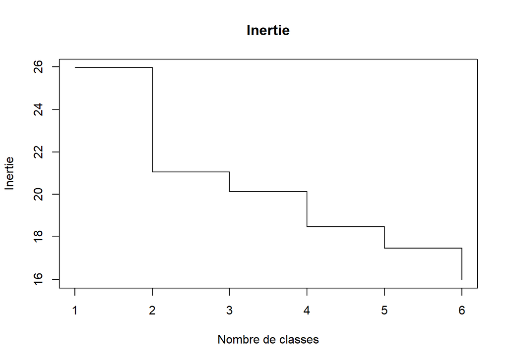

```r
# Utilisation de la première fonction pour afficher le graphique d'inertie

afficher_graphique_inertie(data, "taille_entrep")
```

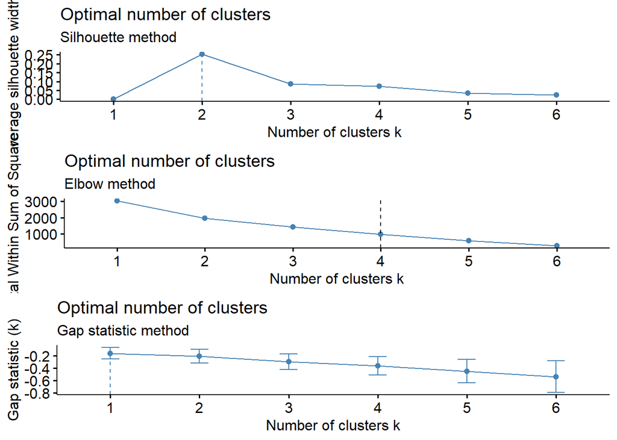

```r
# Utilisation de la deuxième fonction pour organiser les graphiques
organiser_graphiques(data, "taille_entrep")
```

Appel de la fonction 3

```r
# Utilisation de la fonction pour générer les résultats
nbre_choix <- c(2,4)
resultats <- generer_resultats_clustering(data, "taille_entrep", nbre_choix)

# Afficher la matrice finale
print(resultats$results_matrix)
```

```
##                cluster_ 2 cluster_ 4
## average.within 19.4748063 17.7288273
## dunn            1.0710482  0.9757049
## dunn2           1.3327120  1.1352072
## entropy         0.4101163  1.1537419
```

```r
print(resultats$cluster_list)
```

```
## [[1]]
##       variable1 to 50 employees     variable51 to 200 employees
##                               1                               1
##    variable201 to 500 employees   variable501 to 1000 employees
##                               1                               1
##  variable1001 to 5000 employees variable5001 to 10000 employees
##                               1                               1
##        variable10000+ employees
##                               2
##
## [[2]]
##       variable1 to 50 employees     variable51 to 200 employees
##                               1                               2
##    variable201 to 500 employees   variable501 to 1000 employees
##                               1                               1
##  variable1001 to 5000 employees variable5001 to 10000 employees
##                               3                               1
##        variable10000+ employees
##                               4
```

Voici ee qu’on peut dire sur les differentes mesures qui nous aides à évaluer et à comparer les différentes partitions de clusters.

```r
# Changez les modalités
levels(data$taille_entrep)[levels(data$taille_entrep) %in% c("1 to 50 employees" , "51 to 200 employees")] <- "petite"
levels(data$taille_entrep)[levels(data$taille_entrep) %in% c("201 to 500 employees", "501 to 1000 employees" )] <- "moyenne"
levels(data$taille_entrep)[levels(data$taille_entrep) %in% c("1001 to 5000 employees", "5001 to 10000 employees")] <- "grande"
levels(data$taille_entrep)[levels(data$taille_entrep) %in% c("10000+ employees")] <- "tres_grande"

# Vérifiez les niveaux mis à jour
print(levels(data$taille_entrep))
```

```
## [1] "petite"      "moyenne"     "grande"      "tres_grande"
```

##### **Pour la variable “Type_propriete”**

```r
frequency_table <- generate_frequency_table(data, "Type_propriete")
print(frequency_table)
```

```
##                          Modalite Effectif Frequence
## 2               Company - Private     1672     0.513
## 3                Company - Public     1033     0.317
## 8          Nonprofit Organization      188     0.058
## 13 Subsidiary or Business Segment      155     0.048
## 6                      Government       84     0.026
## 1            College / University       76     0.023
## 7                        Hospital       16     0.005
## 4                        Contract       13     0.004
## 10        Private Practice / Firm       10     0.003
## 14                        Unknown        7     0.002
## 9              Other Organization        2     0.001
## 11       School / School District        3     0.001
## 12                  Self-employed        2     0.001
## 5                       Franchise        1     0.000
```

Nous allons commencer a déterminer le nombre de cluster pour agreger les modalité similaire entres elles

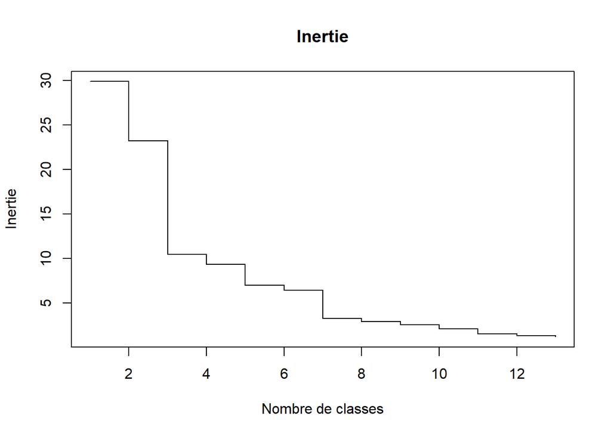

```r
# Utilisation de la première fonction pour afficher le graphique d'inertie

afficher_graphique_inertie(data, "Type_propriete")
```

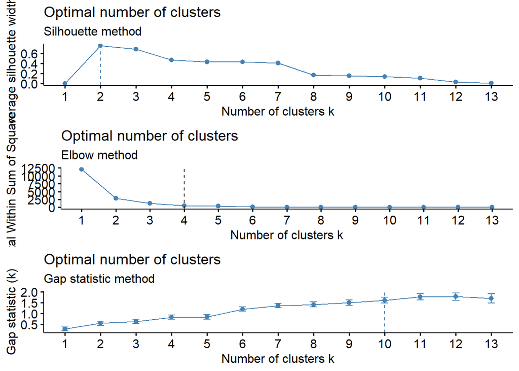

```r
# Utilisation de la deuxième fonction pour organiser les graphiques
organiser_graphiques(data, "Type_propriete")
```

Appel de la fonction 3

```r
# Utilisation de la fonction pour générer les résultats
nbre_choix <- c(2,3,4,10)
resultats <- generer_resultats_clustering(data, "Type_propriete", nbre_choix)

# Afficher la matrice finale
print(resultats$results_matrix)
```

```
##                cluster_ 2 cluster_ 3 cluster_ 4 cluster_ 10
## average.within  8.6107690  5.9541455  5.0507474    1.691890
## dunn            1.1705505  1.7362538  0.8892665    1.048809
## dunn2           3.4703095  3.9001732  2.0731855    1.502364
## entropy         0.2573186  0.5091373  0.7549968    2.064258
```

```r
print(resultats$cluster_list)
```

```
## [[1]]
##           variableCollege / University              variableCompany - Private
##                                      1                                      2
##               variableCompany - Public                       variableContract
##                                      1                                      1
##                      variableFranchise                     variableGovernment
##                                      1                                      1
##                       variableHospital         variableNonprofit Organization
##                                      1                                      1
##             variableOther Organization        variablePrivate Practice / Firm
##                                      1                                      1
##       variableSchool / School District                  variableSelf-employed
##                                      1                                      1
## variableSubsidiary or Business Segment                        variableUnknown
##                                      1                                      1
##
## [[2]]
##           variableCollege / University              variableCompany - Private
##                                      1                                      2
##               variableCompany - Public                       variableContract
##                                      3                                      1
##                      variableFranchise                     variableGovernment
##                                      1                                      1
##                       variableHospital         variableNonprofit Organization
##                                      1                                      1
##             variableOther Organization        variablePrivate Practice / Firm
##                                      1                                      1
##       variableSchool / School District                  variableSelf-employed
##                                      1                                      1
## variableSubsidiary or Business Segment                        variableUnknown
##                                      1                                      1
##
## [[3]]
##           variableCollege / University              variableCompany - Private
##                                      1                                      2
##               variableCompany - Public                       variableContract
##                                      3                                      1
##                      variableFranchise                     variableGovernment
##                                      1                                      1
##                       variableHospital         variableNonprofit Organization
```

[output cut: 8 more lines]

```
## [[4]]
##           variableCollege / University              variableCompany - Private
##                                      1                                      2
##               variableCompany - Public                       variableContract
##                                      3                                      4
##                      variableFranchise                     variableGovernment
##                                      5                                      6
##                       variableHospital         variableNonprofit Organization
##                                      7                                      8
##             variableOther Organization        variablePrivate Practice / Firm
##                                      5                                      9
##       variableSchool / School District                  variableSelf-employed
##                                      5                                      5
## variableSubsidiary or Business Segment                        variableUnknown
##                                     10                                      5
```

On voit cette fois çi nous pouvons faire confiance nos cluster etant données de base seule les modalités private et public se demarqué des autres.

```r
# Changez les modalités
levels(data$Type_propriete)[levels(data$Type_propriete) %in% "Company - Private" ] <- "privee"
levels(data$Type_propriete)[levels(data$Type_propriete) %in% "Company - Public" ] <- "publique"

levels(data$Type_propriete)[c(1, 4:14)] <- "autres"

# Vérifiez les niveaux mis à jour
print(levels(data$Type_propriete))
```

```
## [1] "autres"   "privee"   "publique"
```

##### **Pour la variable “revenue_entrep”**

```r
frequency_table <- generate_frequency_table(data, "revenue_entrep")
print(frequency_table)
```

```
##                            Modalite Effectif Frequence
## 13         Unknown / Non-Applicable      868     0.266
## 12               $10+ billion (USD)      580     0.178
## 7        $100 to $500 million (USD)      335     0.103
## 10           $2 to $5 billion (USD)      210     0.064
## 6         $50 to $100 million (USD)      205     0.063
## 4          $10 to $25 million (USD)      183     0.056
## 9            $1 to $2 billion (USD)      179     0.055
## 2            $1 to $5 million (USD)      139     0.043
## 5          $25 to $50 million (USD)      135     0.041
## 11          $5 to $10 billion (USD)      132     0.040
## 8  $500 million to $1 billion (USD)      114     0.035
## 1        Less than $1 million (USD)       95     0.029
## 3           $5 to $10 million (USD)       87     0.027
```

Nous allons garder toutes les modalités. Pour cette variable nous allons faire une agregation manuelle. Cette approche nous permettra de gérer les modalités rares et similaires de manière plus efficace afin d’avoir une repartion plus homogene :

```r
# Changez les modalités
levels(data$revenue_entrep)[levels(data$revenue_entrep) %in% "Unknown / Non-Applicable"] <- "inconnue"
levels(data$revenue_entrep)[levels(data$revenue_entrep) %in% "$10+ billion (USD)"] <- "+10B"

levels(data$revenue_entrep)[c(8:11)] <- "500M à 10B"
levels(data$revenue_entrep)[c(6:7)] <- "50M à 500M"
levels(data$revenue_entrep)[c(1:5)] <- "-1M à 50M"

# Vérifiez les niveaux mis à jour
print(levels(data$revenue_entrep))
```

```
## [1] "-1M à 50M"  "50M à 500M" "500M à 10B" "+10B"       "inconnue"
```

##### **Pour la variable “secteur”**

```r
frequency_table <- generate_frequency_table(data, "secteur")
print(frequency_table)
```

```
##                              Modalite Effectif Frequence
## 13             Information Technology     1087     0.333
## 6                   Business Services      659     0.202
## 5           Biotech & Pharmaceuticals      282     0.086
## 10                            Finance      264     0.081
## 12                        Health Care      191     0.059
## 14                          Insurance      107     0.033
## 9                           Education       99     0.030
## 15                      Manufacturing       87     0.027
## 11                         Government       78     0.024
## 1                  Accounting & Legal       71     0.022
## 16                              Media       73     0.022
## 22                             Retail       71     0.022
## 2                 Aerospace & Defense       36     0.011
## 19       Oil, Gas, Energy & Utilities       34     0.010
## 8                   Consumer Services       18     0.006
## 18                         Non-Profit       18     0.006
## 23                 Telecommunications       21     0.006
## 24         Transportation & Logistics       16     0.005
## 4    Arts, Entertainment & Recreation       10     0.003
## 7  Construction, Repair & Maintenance       11     0.003
## 20                        Real Estate       10     0.003
## 21  Restaurants, Bars & Food Services        9     0.003
## 3              Agriculture & Forestry        5     0.002
## 25                   Travel & Tourism        4     0.001
## 17                    Mining & Metals        1     0.000
```

l y a quelques problématiques potentielles :

Catégories peu fréquentes : Il y a plusieurs catégories avec un faible nombre d’observations, ce qui peut entraîner une instabilité dans les résultats

Y’aura rien a supprimer ici

- Technologie de l’Information:
  - Information Technology
- Service:
  - Business Services
- Pharmaceutique et Santé:
  - Biotech & Pharmaceuticals
  - Health Care
- Finance et Assurance :
  - Finance
  - Insurance
- Autres :
  - Toutes les autres catégories peu fréquentes.

```r
# Changez les modalités

levels(data$secteur)[levels(data$secteur) %in% "Information Technology"] <- "technologie_infor"
levels(data$secteur)[levels(data$secteur) %in% "Business Services"] <- "services"
levels(data$secteur)[levels(data$secteur) %in% c("Biotech & Pharmaceuticals", "Health Care")] <- "Sciences_Santé"
levels(data$secteur)[levels(data$secteur) %in% c("Finance", "Insurance" )] <- "finance-assurance"


# Liste des catégories à conserver
conserver <- c("Sciences_Santé" , "finance-assurance" , "services" , "technologie_infor")

# Récupérez les niveaux de la variable depuis votre dataframe (je suppose que vous avez déjà 'data' défini ailleurs).
nom_moda <- levels(data$secteur)


# Obtenez les indices des catégories qui ne sont pas dans 'conserver'
indices_non_conserver <- which(!nom_moda %in% conserver)

# Changez les modalités
levels(data$secteur)[indices_non_conserver]= "autres"



cat("les nouvelles modalites:", levels(data$secteur) )
```

```
## les nouvelles modalites: autres Sciences_Santé services finance-assurance technologie_infor
```

```r
frequency_table <- generate_frequency_table(data, "nom_poste")
print( head(frequency_table,10) )
```

```
##                           Modalite Effectif Frequence
## 361                   Data Analyst      201     0.062
## 486                  Data Engineer      201     0.062
## 652                 Data Scientist      199     0.061
## 1687         Senior Data Scientist       78     0.024
## 1654           Senior Data Analyst       41     0.013
## 1135     Machine Learning Engineer       35     0.011
## 225  Business Intelligence Analyst       34     0.010
## 1666          Senior Data Engineer       33     0.010
## 166              Big Data Engineer       30     0.009
## 1108           Lead Data Scientist       22     0.007
```

l y a quelques problématiques potentielles :

Catégories peu fréquentes : Il y a plusieurs catégories avec un faible nombre d’observations, ce qui peut entraîner une instabilité dans les résultats

Nous allons faire une agregation manuelle la aussi. On voit beaucoup de modalité sont redondante. En effet on voit les metiers principaux sont le data scientiste; data analyste, data ingenering avec des specificités qui font multiplié le noms des poste sans compté entre les juniors sceniors etc.

- Du coup nous allons nous concentré 4 modalités:
  - data scientiste
  - data analyste
  - data ingenering
  - autres

Pour mettre en oeuvre ces 4 modalités l’idées et de parcourir chaque modaltité de la variable nom_poste des qu’on voit le mot scientist elle fera partie de la modalité data scientist pareille pour ou analyst ou Engineer et pour tout le reste des metiers qui ne contient pas le mot scientist analyst Engineer elle fera partie de la modalité autres.

```r
# Convertissez le facteur en caractère
data$nom_poste <- as.character(data$nom_poste)


# Remplacer les modalités contenant "analyst" par "data_analyst"
data$nom_poste  <- gsub(".*analyst.*", "data_analyst", data$nom_poste , ignore.case = TRUE)

# Remplacer les modalités contenant "scientist" par "data_scientist"
data$nom_poste  <- gsub(".*scientist.*", "data_scientist", data$nom_poste , ignore.case = TRUE)


# Remplacer les modalités contenant "Engineer" par "data_engineer"
data$nom_poste  <- gsub(".*engineer.*", "data_engineer", data$nom_poste , ignore.case = TRUE)



# Convertir la variable 'nom_poste' en facteur
data$nom_poste <- as.factor(data$nom_poste)

# Imprimer le nombre de niveaux (modalités) de la variable 'nom_poste'
cat("le nombre de modalités apres modification : ", nlevels(data$nom_poste), "\n\n")
```

```
## le nombre de modalités apres modification :  245
```

```r
# Obtenir la liste des modalités de 'nom_poste'
nom_moda = levels(data$nom_poste)

# Créer un vecteur logique pour les modalités à conserver
modalité_garder <- nom_moda == "data_scientist" | nom_moda == "data_analyst" | nom_moda == "data_engineer"

# Remplacer les modalités qui ne sont pas à conserver par "autres"
levels(data$nom_poste)[!modalité_garder] <- "autres"

# verifier

cat("Verification finale :",levels(data$nom_poste))
```

```
## Verification finale : autres data_analyst data_engineer data_scientist
```

Nous venons de finaliser le prétraitemant de ce dataset. On voit finalement mettre en oeuvre une agration automatique s’avere plus compliqué car il se peut que l’indice de smilartié n’etait pas la bonne car manque de coherence…..etc

## Etape 2: Analyse exploratoire des données

Nous utiliserons des graphiques, des statistiques descriptives et des tests statistiques pour explorer les données, identifier les tendances et les relations entre les variables, et répondre aux questions de recherche.

### cas Univariée pour les variables qualitatives

Nous allons verifier ce qu’on a fait …. En regardant la repation de chaque modalité de chaque variable

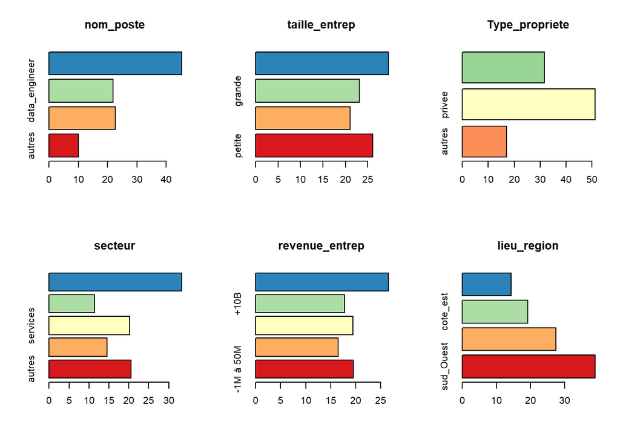

```r
data_quali= data[,c("nom_poste", "taille_entrep", "Type_propriete",  "secteur", "revenue_entrep", "lieu_region")]

par(mfrow = c(2, 3))


for(i in 1:6) {
eff= table(data_quali[,i])
frequence= round(prop.table(eff)*100,2)
barplot( frequence, main=names(data_quali)[i], horiz=T, col=brewer.pal( n = nlevels(data_quali[,i]) , name = "Spectral") )

              }
```

#### **cas bivariée et tests statistiques pour deux variables qualitatives.**

Dans le cadre de notre analyse des données catégorielles, nous avons pour objectif de déterminer si les variables sont dépendantes les unes des autres et le cas échéant, d’évaluer l’intensité de cette dépendance. Pour ce faire, nous commencerons par réaliser des tests d’indépendance, notamment le test du khi-deux (test paramétrique). Toutefois, il est impératif que les effectifs théoriques ne soient pas nuls, et que plus de 80 % d’entre eux soient supérieurs à 5, pour que le test du khi-deux puisse être utilisé en toute fiabilité. Si ces conditions ne sont pas remplies, nous opterons pour le test de Fisher exact (test non paramétrique), plus spécifiquement le test de Fisher-Freeman-Halton. En ce qui concerne les seuils de signification statistique, nous fixerons un seuil de 5 % pour les valeurs de p (p-valeurs). Si une p-valeur est inférieure à 0,05, nous considérerons que le résultat est statistiquement significatif

- Il est essentiel de garder à l’esprit les hypothèses liées à ces deux tests : — H0 : Les deux variables étudiées sont indépendantes. Lorsque la valeur de p (p-valeur) est supérieure ou égale à 0,05, nous n’avons pas de raison de rejeter cette hypothèse nulle. — H1 : Les deux variables étudiées ne sont pas indépendantes. Si la valeur de p est inférieure à 0,05, nous pouvons alors rejeter l’hypothèse nulle.

Après avoir identifié un lien significatif entre deux variables, nous chercherons à mesurer l’intensité de cette association. Pour ce faire, nous utiliserons l’indicateur du V de Cramer, dont la plage de valeurs varie de 0 à 1. Plus le V de Cramer se rapproche de 1, plus l’association entre les variables est forte.

Par ailleurs, nous utilisons des outils de visualisation, notamment le “Diagramme en Tuyaux d’Orgue”, pour représenter graphiquement la répartition des catégories de variables. Cette représentation graphique facilite la compréhension des associations et des différences entre les catégories. Elle constitue notre point de départ pour une meilleure compréhension des liens entre les variables.

Introduction aux Méthodes : Dans le cadre de notre démarche méthodique, nous allons illustrer notre approche en appliquant trois exemples questions ensuite nous verrons directement le tableau de test statistiques. L’idée aussi a travers cette analyse et de voir si ya de la redondance entre nos variables etc.. pour des futur modeles qu’on souhaiterai faire parla suite

L’idée derierre

Analyser les répartitions : Examinez comment les barres se répartissent dans chaque région. Observez si certaines régions ont une prédominance de certains secteurs d’activité.

Comparaison des régions : Comparez la répartition des secteurs d’activité entre les différentes régions. Si vous remarquez des différences significatives, cela pourrait indiquer une relation.

Tests statistiques : Vous pouvez effectuer des tests statistiques pour évaluer la signification des différences. Par exemple, un test de chi-deux (test du chi-deux d’indépendance) peut être utilisé pour vérifier s’il existe une relation significative entre les deux variables. Si la p-valeur du test est faible, cela suggère une relation significative.

Fonction test khi-deux et v.cramer

```r
# Fonction pour effectuer le test du khi2 et calculer le coefficient de Cramer
test_chi2 <- function(data) {
  # Créer un data frame pour stocker les résultats
  resultats <- data.frame(Variable1 = character(0), Variable2 = character(0), Statistique_de_test = numeric(0),
                          p_valeur = numeric(0), ddl = numeric(0), Effectifs_attendus_sup_5 = logical(0),
                          p_valeur_fisher = numeric(0), V_de_Cramer = numeric(0))

  # Sélectionner les colonnes contenant des variables qualitatives
  qual_cols <- names(data)[sapply(data, is.factor)]

  # Itérer sur toutes les paires de variables qualitatives
  for (i in 1:(length(qual_cols) - 1)) {
    for (j in (i + 1):length(qual_cols)) {
      var1 <- qual_cols[i]
      var2 <- qual_cols[j]

      # Effectuer le test du khi2
      contingency_table <- table(data[[var1]], data[[var2]])
      chi2_result <- chisq.test(contingency_table)

      # Calculer le coefficient de V de Cramer
      n <- sum(contingency_table)
      v_cramer <- sqrt(chi2_result$statistic / (n * (min(dim(contingency_table)) - 1)))

      # Effectuer le test de Fisher
      fisher_result <- fisher.test(contingency_table, simulate.p.value = TRUE)

      # Stocker les résultats dans le data frame
      resultats <- rbind(resultats, data.frame(Variable1 = var1, Variable2 = var2,
                                               Statistique_de_test = round(chi2_result$statistic, 2),
                                               p_valeur_khi2 = round(chi2_result$p.value, 3),
                                               ddl = chi2_result$parameter,
                                               Effectifs_attendus_sup_5 = all(chi2_result$expected > 5),
                                               p_valeur_fisher = round(fisher_result$p.value, 3),
                                               V_de_Cramer = round(v_cramer, 3)))
    }
  }

  return(resultats)
}

# Utilisation de la fonction
resultats_khi2 <- test_chi2(data_quali)  # Assurez-vous de remplacer "data_quali" par le nom de votre jeu de données
```

**Question 1: Concernant les variables nom_poste et region**

1.1- Questions distributions conditionnelles types de poste en fonction des regions. L’idée va etre examinez comment la variable “nom_poste” est répartie conditionnellement à la variable “Région” afin d’avoir une idée s’il existe un lien entre les variables. Il y’aura deux axes de questions qui se portera sur l’analyse des repartions et sur la comparaison des categories:

- Axe “Analyse des répartitions”: - Quel est le type de poste le plus fréquent dans chaque région ? - Y a-t-il des différences significatives dans la répartition des types de postes entre les régions ? - Existe-t-il des régions où un certain type de poste est prédominant par rapport aux autres régions ?
- Axe “Comparaison des catégories” : - Est-ce que la répartition de certains postes varie considérablement d’une région à l’autre ? - Quels types de postes sont plus fréquents dans les régions cote_Ouest par rapport aux régions cote_Est ? - Existe-t-il des régions où la répartition des postes data analyste diffère significativement des autres régions ?

- Le type de poste cherché est il indépendant de la région ?

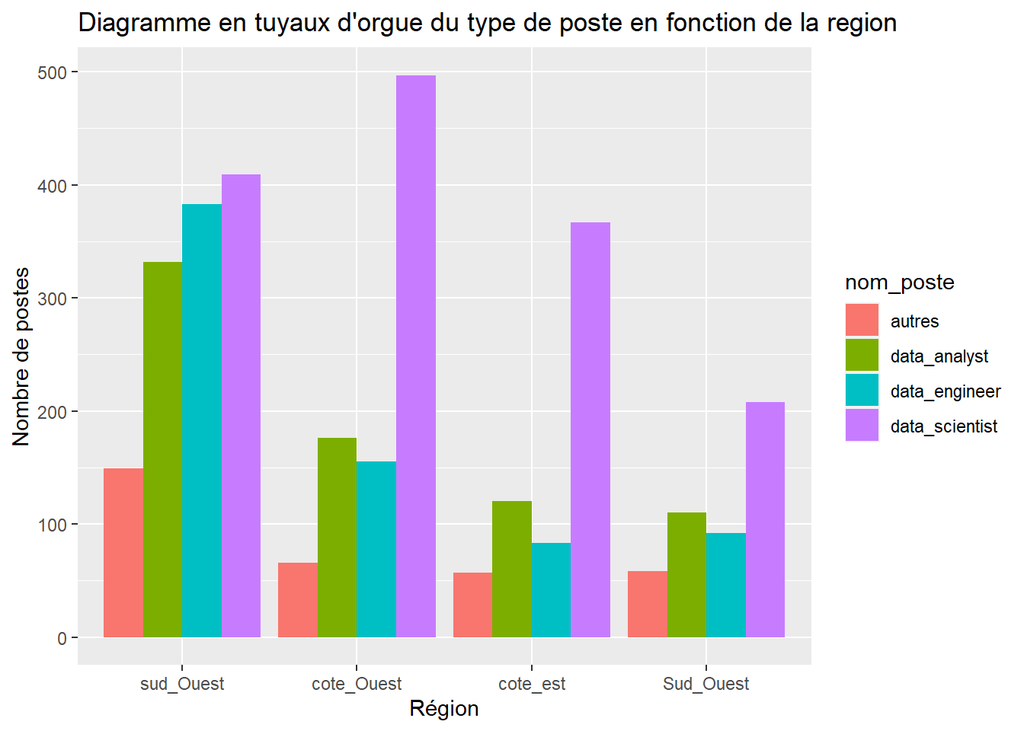

```r
# question 1:


# Création d'un graphique à barres empilées avec ggplot2
bar <- ggplot(data, aes(x = lieu_region, fill = nom_poste)) +
  geom_bar(position = "dodge") +
  labs(title = "Diagramme en tuyaux d'orgue du type de poste en fonction de la region",  # Titre du graphique
       x = "Région",  # Légende de l'axe des x
       y = "Nombre de postes")  # Légende de l'axe des y

# Afficher le graphique
print(bar)
```

```r
# question 2:

print( subset(resultats_khi2, Variable1=="nom_poste" & Variable2=="lieu_region") )
```

```
##            Variable1   Variable2 Statistique_de_test p_valeur_khi2 ddl
## X-squared4 nom_poste lieu_region              190.38             0   9
##            Effectifs_attendus_sup_5 p_valeur_fisher V_de_Cramer
## X-squared4                     TRUE               0       0.139
```

Reponse:

**Question 2: Concernant les variables secteurs d’activités et region**

2.1- Questions distributions conditionnelles du secteurs d’activités en fonction des regions. L’idée va etre examinez comment la variable “secteur” est répartie conditionnellement à la variable “Région” afin d’avoir une idée s’il existe un lien entre les variables. Il y’aura deux axes de questions qui se portera sur l’analyse des repartions et sur la comparaison des categories:

- Axe “Analyse des répartitions”: - Quel est le secteur d’activité le plus fréquent dans chaque région ? - Y a-t-il des différences significatives dans la répartition des secteurs d’activités entre les régions ? - Existe-t-il des régions où un certain type secteur d’activité est prédominant par rapport aux autres régions ?

Axe “Comparaison des catégories” : - Est-ce que la répartition de certains secteurs varie considérablement d’une région à l’autre ? - Quels types de secteurs sont plus fréquents dans les régions cote_Ouest par rapport aux régions cote_Est ? - Existe-t-il des régions où la répartition des secteurs d’activités diffère significativement des autres régions ?

En répondant à ces questions, vous pourrez obtenir des indications sur l’existence d’un lien entre les variables “secteur” et “Région”. Cependant, il est important de noter que pour une analyse plus approfondie et pour établir des conclusions solides, il peut être nécessaire d’utiliser des méthodes statistiques appropriées.

- Le type de industrie cherché est il indépendant de la région ?

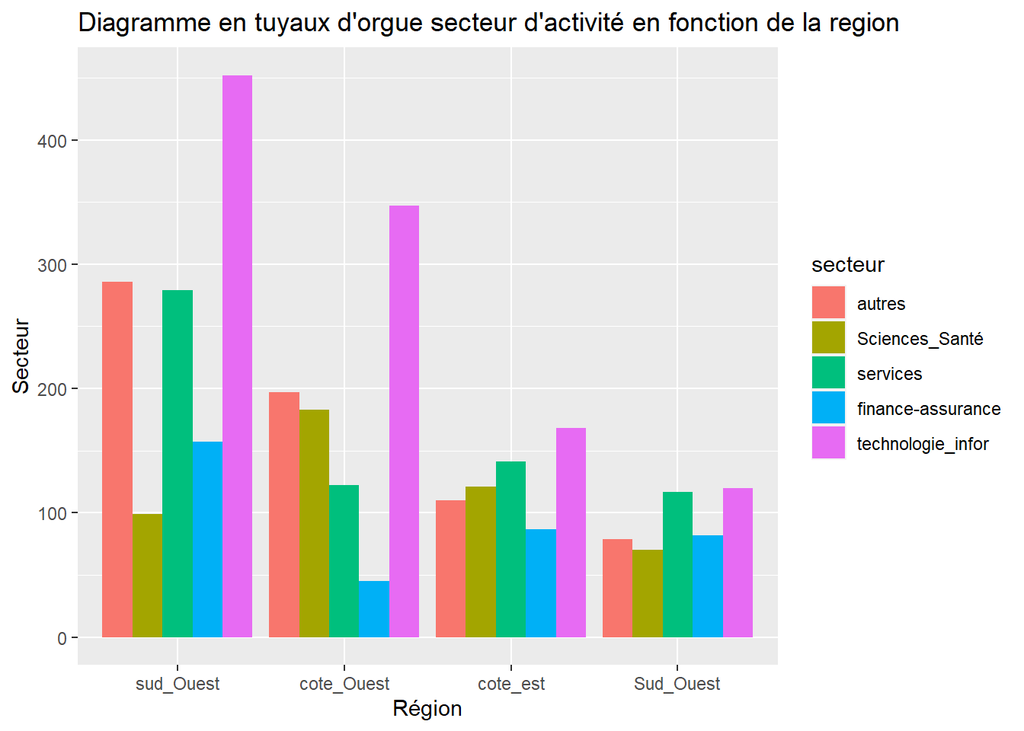

```r
# question 1:


# Création d'un graphique à barres empilées avec ggplot2
bar <- ggplot(data, aes(x = lieu_region, fill = secteur)) +
  geom_bar(position = "dodge") +
  labs(title = "Diagramme en tuyaux d'orgue secteur d'activité en fonction de la region",  # Titre du graphique
       x = "Région",  # Légende de l'axe des x
       y = "Secteur")  # Légende de l'axe des y

# Afficher le graphique
print(bar)
```

```r
# question 2:

print( subset(resultats_khi2, Variable1=="secteur" & Variable2=="lieu_region") )
```

```
##             Variable1   Variable2 Statistique_de_test p_valeur_khi2 ddl
## X-squared13   secteur lieu_region              186.38             0  12
##             Effectifs_attendus_sup_5 p_valeur_fisher V_de_Cramer
## X-squared13                     TRUE               0       0.138
```

Reponse:

**Question 3: Concernant les variables revenue d’entreprise et taille d’entreprise**

3.1- Questions distributions conditionnelles du revenue d’entreprise en fonction de la taille d’entreprise. L’idée va etre examinez comment la variable “revenue-entrep” est répartie conditionnellement à la variable “taille_entrep” afin d’avoir une idée s’il existe un lien entre les variables. Il y’aura deux axes de questions qui se portera sur l’analyse des repartions et sur la comparaison des categories:

- Axe “Analyse des répartitions”: - Quelle est la répartition des revenus des entreprises en fonction de leur taille ? - Y a-t-il des différences significatives dans la répartition des revenus entre les différentes tailles d’entreprises ? - Existe-t-il une taille d’entreprise prédominante pour certains niveaux de revenus ?
- Axe “Comparaison des catégories” : - Comment les revenus des entreprises varient-ils en fonction de leur taille ? Y a-t-il une tendance générale ? - Quelles sont les différences de revenus entre les différentes tailles d’entreprises ? - Existe-t-il des tailles d’entreprises où les revenus sont significativement plus élevés ou plus faibles par rapport aux autres tailles d’entreprises ?

- Le revenue d’une entreprise depend til de la taille de l’entreprise ?

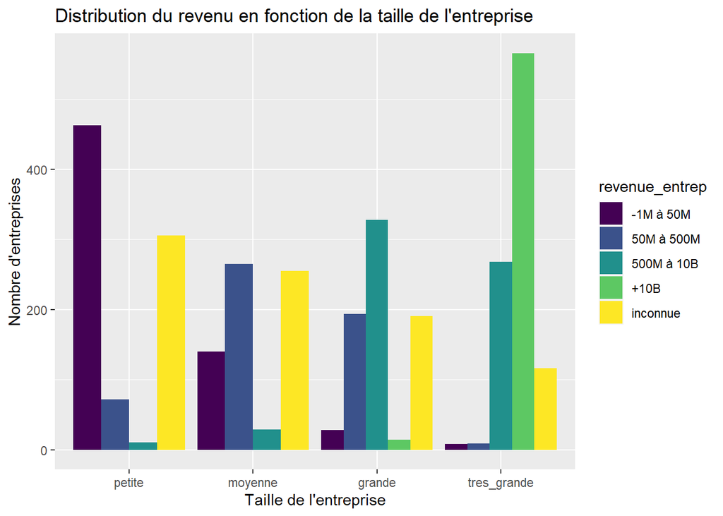

```r
# Création d'un graphique à barres empilées avec ggplot2
bar <- ggplot(data, aes(x = taille_entrep, fill = revenue_entrep)) +
  geom_bar(position = "dodge") +
  labs(title = "Distribution du revenu en fonction de la taille de l'entreprise",
       x = "Taille de l'entreprise",
       y = "Nombre d'entreprises")  # Utilisation du nombre d'entreprises plutôt que du revenu pour l'axe y

# Afficher le graphique
print(bar)
```

```r
# question 2:

subset(resultats_khi2, Variable1=="revenue_entrep" & Variable2=="taille_entrep")
```

[output not shown]

```
## [1] Variable1                Variable2                Statistique_de_test
## [4] p_valeur_khi2            ddl                      Effectifs_attendus_sup_5
## [7] p_valeur_fisher          V_de_Cramer
## <0 lignes> (ou 'row.names' de longueur nulle)
```

Reponse:

- Axe “Analyse des répartitions”: - Quelle est la répartition des revenus des entreprises en fonction de leur taille ? - Y a-t-il des différences significatives dans la répartition des revenus entre les différentes tailles d’entreprises ? On constate des différences significatives dans la répartition des revenus entre les différentes tailles d’entreprises. En effet selon la taille de l’entreprise le revenue de l’entreprise est proportionnelle. Pour une petite entreprise le revenue sera majoritairement le plus petit. Pour une moyenne moyenne grande grande et tres grande rande
- Axe “Comparaison des catégories” : - Comment les revenus des entreprises varient-ils en fonction de leur taille ? Y a-t-il une tendance générale ? oui - Y a-t-il une relation entre la taille de l’entreprise et son revenu ? : On constate il e existe une tendance qui montre que les entreprises de petite taille on un revenue faible , entreprise de taille moyenne on un revenu moyen etc.. cela est bien proportionnelle en fonction de la taille et du revenue

Y a-t-il des catégories de taille qui se distinguent par leur distribution de revenu ? : On constate les catégories de taille où la distribution du revenu est notablement différente des autres et pour les petites et tres grandes entreprises avec un faible et grand revenue. Cela peut indiquer des disparités significatives entre les segments du marché.

Tests statistiques

### cas Univariée pour les variables quantitatives

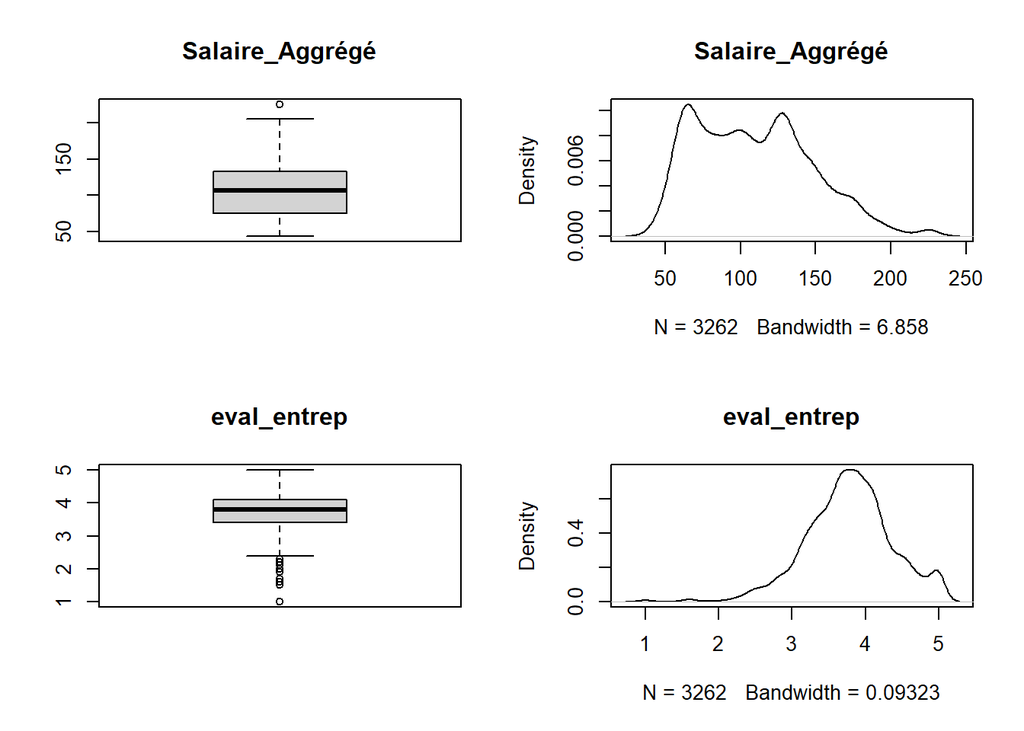

```r
data_quanti= data[,c("Salaire_Aggrégé","eval_entrep")]


par(mfrow=c(2,2))
for (i in 1:length(data_quanti)) {
  boxplot(data_quanti[,i], main=names(data_quanti[i]), type="l")
  plot(density(data_quanti[,i]), main=names(data_quanti)[i])
  }
```

#### **cas bivariée et tests statistiques pour deux variables quantitatives.**

```r
cor_pear= cor.test(data_quanti$eval_entrep, data_quanti$Salaire_Aggrégé, method = "pearson")
cor_spear= cor.test(data_quanti$eval_entrep, data_quanti$Salaire_Aggrégé, method = "spearman")
cor_ken= cor.test(data_quanti$eval_entrep, data_quanti$Salaire_Aggrégé, method = "kendall")

#print("l'intensité est:", cor_pear)
print(cor_pear)
```

```
##
##  Pearson's product-moment correlation
##
## data:  data_quanti$eval_entrep and data_quanti$Salaire_Aggrégé
## t = 5.1715, df = 3260, p-value = 2.462e-07
## alternative hypothesis: true correlation is not equal to 0
## 95 percent confidence interval:
##  0.05606005 0.12414030
## sample estimates:
##        cor
## 0.09020556
```

```r
print(cor_spear)
```

```
##
##  Spearman's rank correlation rho
##
## data:  data_quanti$eval_entrep and data_quanti$Salaire_Aggrégé
## S = 5.233e+09, p-value = 4.756e-08
## alternative hypothesis: true rho is not equal to 0
## sample estimates:
##        rho
## 0.09542035
```

```r
print(cor_ken)
```

```
##
##  Kendall's rank correlation tau
##
## data:  data_quanti$eval_entrep and data_quanti$Salaire_Aggrégé
## z = 5.4326, p-value = 5.554e-08
## alternative hypothesis: true tau is not equal to 0
## sample estimates:
##        tau
## 0.06545788
```

```r
library(MASS)

transformation_variable <- function(data, variable) {

  # Appliquer la transformation Box-Cox
  boxcox_result <- boxcox(data[[variable]]~1)
  lambda <- boxcox_result$x[which.max(boxcox_result$y)]  # Utilisez boxcox_result ici
  print(paste("La meilleure valeur de lambda est:", lambda))

  # Appliquer la transformation à votre variable
  transformed_box_cox <- (data[[variable]]^lambda - 1) / lambda  # Utilisez data[[variable]] ici

  # Appliquer une transformation logarithmique (log base 10)
  transformed_log <- log10(data[[variable]])

  # Appliquer une transformation racine carrée
  transformed_sqrt <- sqrt(data[[variable]])

  # Appliquer une transformation racine cubique
  transformed_cubique <- data[[variable]]^(1/3)

  # Stocker les données transformées dans un data frame
  transformed_data <- data.frame(BoxCox = transformed_box_cox,
                                  Log = transformed_log,
                                  Sqrt = transformed_sqrt,
                                  CubicRoot = transformed_cubique)

  return(transformed_data)
}
```

```r
transfor_sal <- transformation_variable(data_quanti, "Salaire_Aggrégé")
```

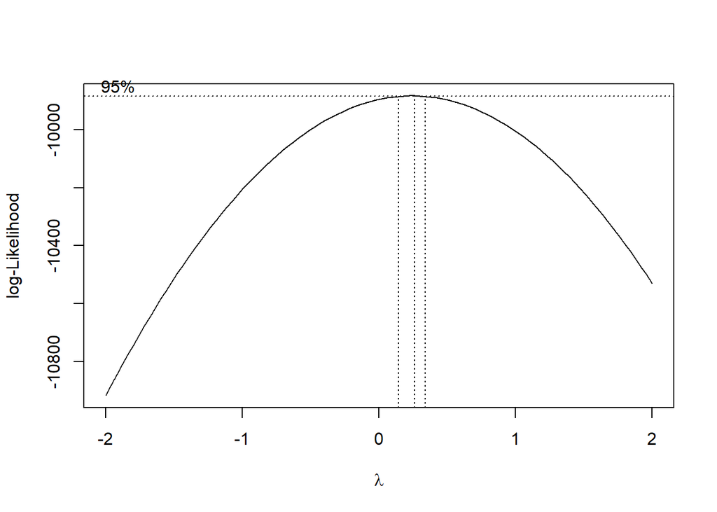

```
## [1] "La meilleure valeur de lambda est: 0.262626262626263"
```

```r
colnames(transfor_sal)= c("BoxCox_sal", "Log_sal", "Sqrt_sal", "cubic_sal")

transfor_eval <- transformation_variable(data_quanti, "eval_entrep")
```

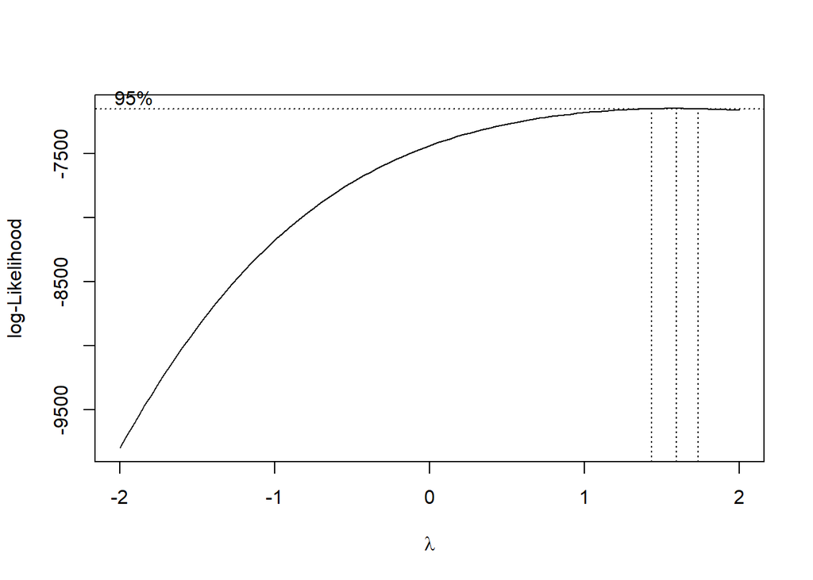

```
## [1] "La meilleure valeur de lambda est: 1.5959595959596"
```

```r
colnames(transfor_eval)= c("BoxCox_eval", "Log_eval", "Sqrt_eval", "cubic_eval")
```

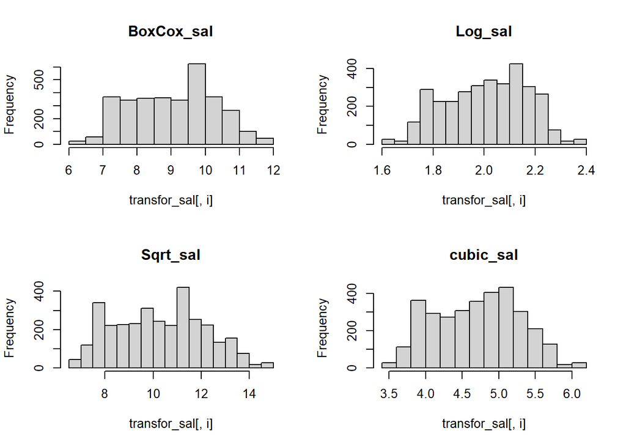

```r
par(mfrow=c(2,2))
for (i in 1:length(transfor_sal)) {
  hist(transfor_sal[,i], main=names(transfor_sal[i]))
  }
```

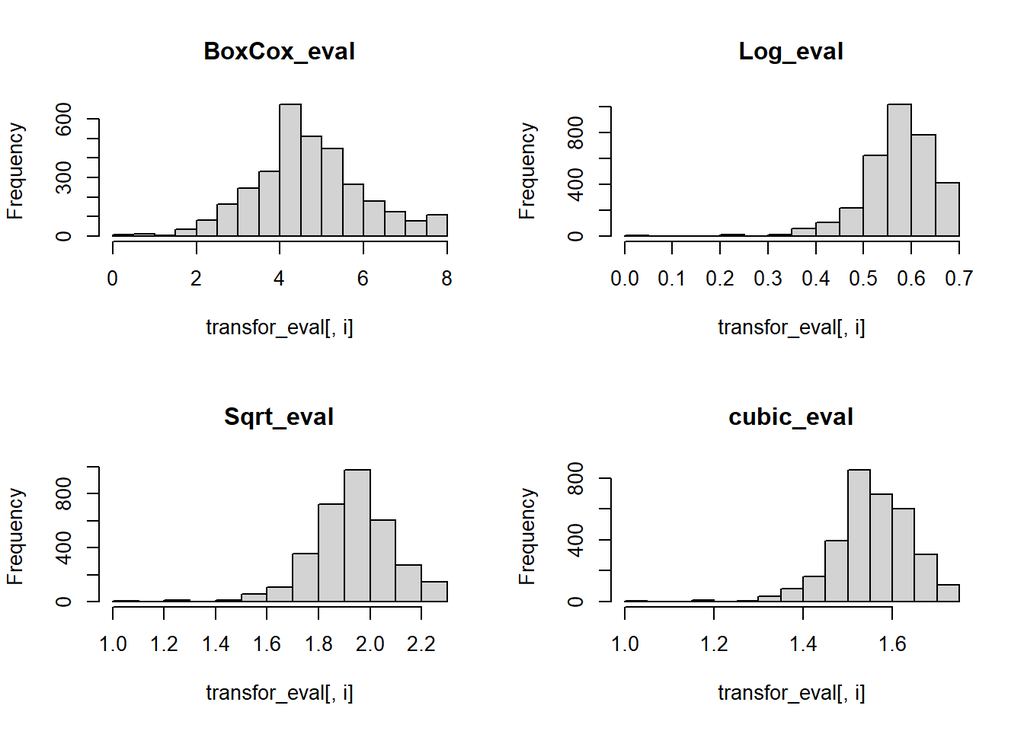

```r
par(mfrow=c(2,2))
for (i in 1:length(transfor_eval)) {
  hist(transfor_eval[,i], main=names(transfor_eval[i]))
  }
```

```r
table(data_quanti$eval_entrep)
```

```
##
##   1 1.5 1.6 1.7 1.9   2 2.1 2.2 2.3 2.4 2.5 2.6 2.7 2.8 2.9   3 3.1 3.2 3.3 3.4
##   6   1   9   1   1   2   2   7   9  18  30  26  27  55  54  55 109 135 151 179
## 3.5 3.6 3.7 3.8 3.9   4 4.1 4.2 4.3 4.4 4.5 4.6 4.7 4.8 4.9   5
## 163 231 279 218 292 186 263 148 115  75 103  71  55  39  39 108
```

```r
# 111  868 1002 1300 1385 2070
# 3262

d= data_quanti[data_quanti$eval_entrep!=1,]
dim(d)
```

```
## [1] 3256    2
```

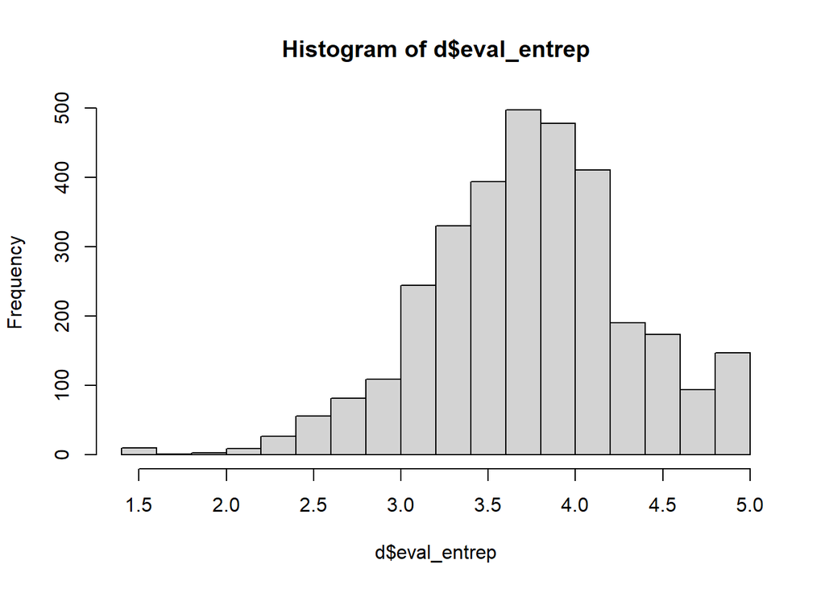

```r
hist(d$eval_entrep)
```

## **Modélisation statistique**

L’idée dans cette section est de formuler des questions pour élaborer des modèles statistiques conformément à notre objectif. Les modèles statistiques ont principalement deux objectifs :

- 1. **Inférence Statistique :** L’objectif principal est d’obtenir des informations sur les relations entre les variables, y compris la détermination des coefficients des variables indépendantes, la signification statistique de ces coefficients, et la compréhension de la force et de la direction des relations. L’inférence statistique est couramment utilisée dans la recherche pour tester des hypothèses et comprendre comment les variables sont liées dans la population étudiée.
- 2. **Prévision :** Les modèles statistiques peuvent également être utilisés à des fins de prévision. Dans ce cas, le modèle est construit pour prédire une variable dépendante à partir de variables indépendantes. Cependant, la qualité prédictive varie en fonction des données, du modèle, et de la pertinence des variables. Des méthodes comme la régression linéaire, axées sur l’inférence statistique, ne sont pas toujours optimales pour la prévision, tandis que des techniques dédiées comme l’apprentissage automatique sont spécifiquement conçues pour cette finalité.

**Notre première question est de rechercher:** s’il existe une influence statistique entre l’évaluation de l’entreprise et le salaire des employés?.

**Objectif de l’Analyse - Explicatif :** Nous cherchons à comprendre la relation entre l’évaluation de l’entreprise (variable indépendante) et les salaires des employés (variable dépendante), soulevant des questions subsidiaires telles que :

- Nature de la relation : Comment la notation de l’entreprise est-elle liée aux salaires des employés?
- Inférence Statistique : Quelle est la relation entre la notation de l’entreprise et les salaires des employés? Les coefficients des variables explicatives sont-ils statistiquement significatifs?
- Qualité du modèle : Dans quelle mesure le modèle explique-t-il et prédit-il correctement les données?
- Satisfaction des hypothèses : Les hypothèses du modèle sont-elles respectées pour assurer une interprétation correcte?
- Modèles alternatifs : Quels autres modèles pourraient mieux s’adapter aux objectifs, compte tenu de la complexité des relations sous-jacentes?

### Evaluation visuelle de la linéarité

Comme nous l’avons rappeler précédament la régression linéaire simple permet d’évaluer la significativité du lien linéaire entre deux variables. La forme linéaire entre le deux variables est donc pré-supposée. Autrement dit, on fait l’hypothèse que la forme de la relation entre les variables est linéaire. C’est ce que nous allons voir ici.

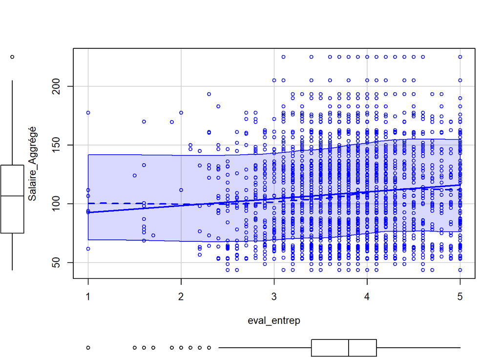

```r
scatterplot( Salaire_Aggrégé~eval_entrep, data=data_quanti)  # permet de faire hypothèse que la forme de la relation entre les                                                                      variables est linéaire
```

```r
# la ligne en trait plein est la droite de régression linéaire (définie par la méthode des moindres carrés) entre les deux variables

# la ligne centrale en pointillé est la courbe de régression locale de type lowess. Elle indique la tendance globale entre les deux     variables.
# Les deux lignes extérieures représentent un intervalle de confiance de la courbe lowess.
```

De plus, la présence de ‘mini groupes’ ou de grappes verticales dans les données suggère des sous-groupes de données similaires nécessitant une exploration plus approfondie.

Nous envisageons initialement un modèle linéaire, mais il est probable que ce modèle présente des limitations à plusieurs niveaux. Avec une corrélation relativement faible entre les variables, le modèle de régression linéaire risque de manquer de prédictivité et d’expliquer seulement une faible proportion de la variation de la variable dépendante (Y).

Si la relation s’avère plus complexe, non linéaire, ou si des sous-groupes de données ont été identifiés, il serait judicieux de considérer des modèles de régression non linéaires ou robustes, voire des modèles de régression multiple, pour mieux refléter les caractéristiques et facteurs influents dans nos données.

### Réalisation d’un modéle régression lineaire simple

On rappelle la régression linéaire simple est une méthode statistique utilisée pour modéliser la relation entre une variable dépendante (Y) et une variable indépendante (X). L’objectif principal est d’ajuster une ligne de régression qui minimise la somme des carrés des écarts entre les valeurs observées et les valeurs prédites. Cette approche, connue sous le nom de méthode des moindres carrés, vise à trouver les coefficients du modèle qui minimisent la variance des résidus, assurant ainsi une prédiction précise.

La minimisation de la variance des résidus contribue à obtenir une estimation robuste et stable, influençant positivement la qualité globale du modèle.

Une faible variance des résidus indique également une meilleure capacité du modèle à généraliser à de nouvelles données, renforçant ainsi sa fiabilité et sa validité statistique. Cela a des implications directes sur les propriétés du modèle de régression linéaire simple, notamment :

- 1. **Absence de Biais :** La méthode des moindres carrés vise à minimiser les erreurs résiduelles, garantissant ainsi que le modèle n’introduit pas de biais significatif dans ses prédictions.
- 2. **Convergence des Coefficients :** Les coefficients de la régression convergent vers des valeurs spécifiques, assurant la stabilité du modèle et la fiabilité des estimations statistiques.

Enfin Les propriétés du modèle de régression linéaire simple, telles que l’absence de biais, la convergence des coefficients, et la validité des tests de significativité et des intervalles de confiance, reposent largement sur certaines hypothèses fondamentales concernant les erreurs du modèle.

Assurer la conformité à ces hypothèses est essentiel pour garantir la fiabilité et l’interprétabilité des résultats obtenus à partir du modèle. Cela permet également de maintenir l’intégrité des analyses statistiques et d’obtenir des conclusions robustes basées sur des fondements solides. La vérification de ces hypothèses fait partie intégrante du processus de modélisation statistique pour s’assurer que le modèle est approprié pour les données disponibles.

**Hypothèses de la Régression Linéaire Simple :**

1. **Linéarité :** L’hypothèse de linéarité stipule que la relation entre la variable indépendante (X) et la variable dépendante (Y) est linéaire. Si cette hypothèse n’est pas satisfaite, les prédictions du modèle peuvent être biaisées et peu fiables.
2. **Homoscédasticité :** L’hypothèse d’homoscédasticité stipule que la variance des erreurs est constante à tous les niveaux de la variable indépendante. Si cette hypothèse n’est pas respectée, les résidus peuvent présenter un schéma systématique, ce qui affecte la validité des tests statistiques.
3. **Indépendance des Résidus :** Les résidus ne montrent pas de structure temporelle ou spatiale. Cette hypothèse garantit que les résidus (différences entre les valeurs observées et prédites) ne sont pas corrélés entre eux. Si cette hypothèse est violée, cela peut entraîner une mauvaise estimation des coefficients et une surestimation de la précision du modèle.
4. **Normalité des Résidus :** Les résidus suivent une distribution normale. Cette hypothése est importante pour l’application de tests statistiques et d’intervalles de confiance. Si les erreurs ne suivent pas une distribution normale, cela peut influencer la validité des tests d’hypothèses.
5. **Pas de Multicolinéarité :** Cette hypothèse stipule que les variables indépendantes ne sont pas fortement corrélées entre elles. La multicolinéarité peut rendre les estimations des coefficients instables et difficiles à interpréter.

En vérifiant ces hypothèses, on s’assure que le modèle est approprié pour les données spécifiques sur lesquelles il est appliqué. Cela permet également de garantir la robustesse des résultats, d’interpréter correctement les coefficients et d’éviter des conclusions erronées basées sur un modèle inapproprié.

```r
# Pour déterminer la droite de régression, on ajuste un modèle linéaire simple aux données, à l’aide de la fonction “lm”

reg= lm(Salaire_Aggrégé ~ eval_entrep, data= data_quanti)
```

Nous débuterons en examinant le nuage de points des résidus de la régression, ce qui constitue un point de départ essentiel pour détecter d’éventuelles anomalies. Nous vérifierons si :

- Le nuage de points présente une répartition aléatoire sans structure particulière,
- Il démontre une symétrie par rapport à l’axe des abscisses.

Si ces conditions sont satisfaites, nous pourrons alors admettre que les résidus suivent une distribution normale ε∼N(0,σ2I). Bien sûr nous vérifions chaque hypothèse. De plus cela permet de vérifier si nous sommes en présence éventuelle points aberrants, atypiques.

**Analyse graphique principale :** Nous construisons le nuage de points {(i, ei); i ∈ {1, . . . , n}}

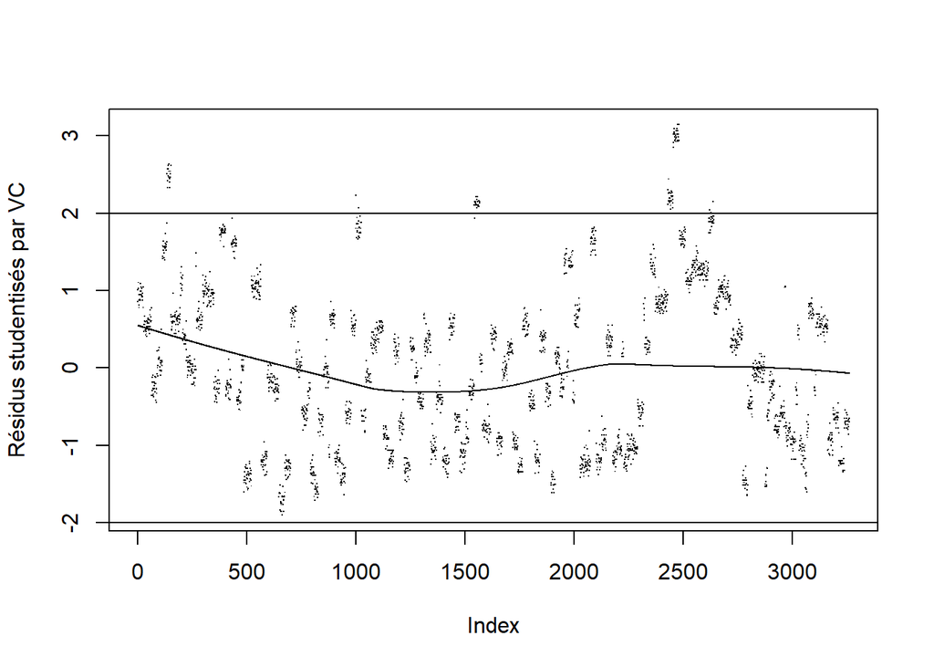

```r
# les résidus studentisés des oberservations

plot(rstudent(reg), pch = ".",ylab = "Résidus studentisés par VC")
abline(h = c(-2,2))
lines(lowess(rstudent(reg)))
```

```r
## compter le nombre observation qui est mal expliquée par le modèle

e = rstandard(reg)
# e[abs(e) > 2]
length(e[abs(e) > 2])/nrow(data) *100     # 3.061
```

```
## [1] 3.065604
```

Pour débuter, il est crucial de remarquer que le nuage de points des résidus studentisés présente une structure en forme de sinusoïde en fonction des individus. Cette observation suggère qu’il existe une certaine organisation ou tendance dans les résidus, pouvant indiquer une violation sérieuse de l’une ou plusieurs des hypothèses sous-jacentes au modèle de régression. Plus précisément, cela suggère que le modèle de régression linéaire simple pourrait ne pas être le choix approprié pour ces données.

Afin d’évaluer cette situation de manière plus approfondie, nous allons examiner en détail chacune des hypothèses sous-jacentes au modèle de régression et déterminer si elles sont respectées ou violées. Cela nous permettra de mieux comprendre la nature de la structure en sinusoïde que nous observons dans les résidus et de décider des étapes à suivre pour ajuster notre modèle en conséquence.

Il est à noter qu’un groupe d’observations situé en haut à droite du graphique se distingue en étant nettement éloigné de l’axe horizontal. Ces observations peuvent sembler atypiques ou aberrantes par rapport à la tendance générale des résidus. Ces observations sont donc mal expliquées par le modèle à une variable. Ces points sont mal prédits mais ne sont pas forcément influents et ne faussent donc pas nécessairement le modèle. C’est pour cette raison que nous allons vérifier aussi si des points leviers ou des observations influentes sont présents.

**Pour évaluer la robustesse du modéle nous allons commencer par analyser en détailles:**

- Points Leviers et Observations Influences
- Structure des residus

**Vérification des Points Aberrants, Levier et Influents :**

Cette première analyse des résidus a pour objectif de détecter la présence de points aberrants, de points levier, et de points influents. Pour identifier les points aberrants, nous évaluons la qualité de l’ajustement en examinant les résidus associés à chaque observation. Un résidu significativement élevé par rapport au seuil défini par la loi de Student indique qu’une observation est considérée comme aberrante, c’est-à-dire mal expliquée par le modèle.

L’identification des points levier repose sur l’analyse de la matrice de projection, qui mesure le poids $h_{ii}$ de chaque observation en fonction des valeurs des variables explicatives. Un point est considéré comme levier si la valeur $h_{ii}$ de la matrice de projection dépasse certains seuils, tels que $2p/n$ selon Hoaglin et Welsch (1978), $3p/n$ pour $p > 6$ et $n - p > 12$ selon Velleman et Welsh (1981), et $0.5$ selon Huber (1981).

En ce qui concerne les points influents, nous utilisons la distance de Cook. Cette mesure évalue l’influence d’une observation $i$ sur l’estimation des paramètres du modèle. Une observation est considérée comme influente si son retrait entraîne une variation significative dans l’estimation des coefficients, indiquée par une distance de Cook élevée. Le seuil critique pour la distance de Cook est déterminé par le quantile $F_{p,n-p}(0.5)$. Une distance de Cook inférieure à $F_{p,n-p}(0.1)$ est considérée comme souhaitable selon Cook (1977).

Cette étape de vérification permet d’assurer la fiabilité du modèle en identifiant les observations qui peuvent avoir un impact significatif sur les résultats de la régression.

```r
############################
## Détection des Points Levier :
################################

# Matrice de projection

projection_matrix <- hatvalues(reg)

  # Seuils pour les points levier

seuil_h1 <- 2 * length(coef(reg)) / length(residuals)

seuil_h2 <- 3 * length(coef(reg)) / (length(residuals) - length(coef(reg)))

seuil_h3 <- 0.5


# Identifier les points levier

levier_indices <- which(projection_matrix > seuil_h1 | (length(coef(reg)) > 6 & projection_matrix > seuil_h2) | projection_matrix > seuil_h3)

levier_observations <- data.frame(Observation = levier_indices, Levier = projection_matrix[levier_indices])



###################################################
## Détection des Points Influents (Distance de Cook) :
######################################################

# Calcul de la distance de Cook

cook_distance <- cooks.distance(reg)

  # Seuil critique (quantile Fp,n-p(0.5))

seuil_cook <- qf(0.5, length(coef(reg)), length(residuals) - length(coef(reg)))
# Identifier les observations influentes

influentes_indices <- which(cook_distance > seuil_cook)

influentes_observations <- data.frame(Observation = influentes_indices, Cook_Distance = cook_distance[influentes_indices])
```

```r
print(levier_observations)
```

```
## [1] Observation Levier
## <0 lignes> (ou 'row.names' de longueur nulle)
```

```r
print(influentes_observations)
```

```
## [1] Observation   Cook_Distance
## <0 lignes> (ou 'row.names' de longueur nulle)
```

```r
seuil_h1
```

```
## [1] 4
```

```r
seuil_h2
```

```
## [1] -6
```

```r
par(mfrow=c(1,2))

# points de levier

p <- length(reg$coef)
n <- nrow(data)

infl.reg <- influence.measures(reg)
plot(infl.reg$infmat[,"hat"],type="h",ylab="hii", main="Point levier")
seuil1 <- 3*p/n ; abline(h=seuil1,col=1,lty=2)
seuil2 <- 2*p/n ; abline(h=seuil2,col=1,lty=3)

seuil1
```

```
## [1] 0.001839362
```

```r
seuil2
```

```
## [1] 0.001226242
```

```r
length(which(infl.reg$infmat[,"hat"]>seuil1))
```

```
## [1] 56
```

```r
length(which(infl.reg$infmat[,"hat"]>seuil2))
```

```
## [1] 325
```

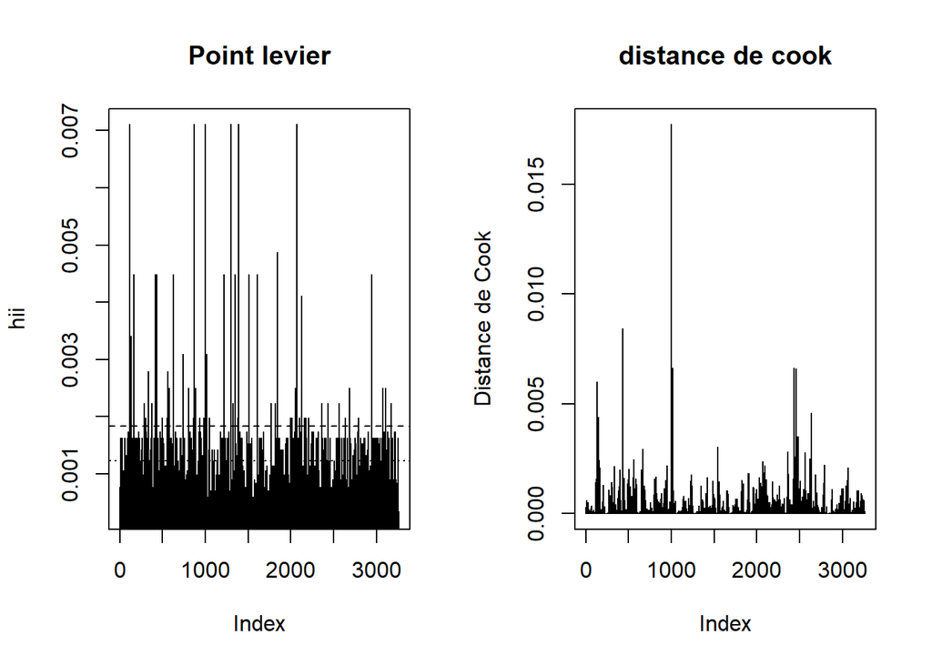

```r
# points influents

plot(cooks.distance(reg),type="h",ylab="Distance de Cook", main="distance de cook")
seuil1 <- qf(0.1,p,n-p) ; abline(h=seuil1)
```

```r
qf(0.1,p,n-p) ##  Une distance de Cook en-dessous de fp,n−p(0.1) est considéré comme souhaitable
```

```
## [1] 0.1053639
```

```r
qf(0.5,p,n-p) ##   seuil critique pour la distance de Cook à partir duquel on considère que l’observation est trop influente est le                    quantile fp,n−p(0.5)
```

```
## [1] 0.6932946
```

On constate pour

1. **Distance de Cook :**

L’idée si les individus pour lesquels leur distance de Cook associée est supérieur au seuil fp,n−p(0.1) = 0.105 sont considérés comme potentiellement aberrants et ceux dont leur distance est supérieur au seuil fp,n−p(0.5) = 0.693 sont considérés comme aberrant et trop influant dans le modèle.

2. **Points Leviers :**

**Conclusion :**

#### **Vérification des hypothéses**

**1- hypohthése Adequation (Linearité) et Normalité**

Concernant l’hypothèse d’adéquation linéaire postule l’indépendance des résidus par rapport aux variables indépendantes (explicatives) du modèle de régression. Cette hypothèse revêt une importance cruciale pour s’assurer que la relation entre la variable dépendante et les variables indépendantes est correctement capturée par le modèle linéaire.

Pour évaluer cette hypothèse, divers outils graphiques peuvent être utilisés, parmi lesquels les graphiques “Residuals vs Fitted” et “Residuals vs variable_explicative”. Ces graphiques permettent une inspection visuelle de l’absence de structure systématique dans la distribution des résidus par rapport aux valeurs ajustées ou aux variables indépendantes.

De plus, un test de rainbow peut être appliqué pour quantifier la non-linéarité dans le modèle. Ce test examine la pertinence de l’ajout de termes non linéaires dans la spécification du modèle. Un rejet significatif de l’hypothèse nulle du test de rainbow suggère une non-linéarité résiduelle dans le modèle, indiquant ainsi une possible violation de l’adéquation linéaire.

Conernant l’hypothése de normalité pourl’évaluer nous allons tracé le nuage de points QQ plot associé (ou diagramme Quantile-Quantile). Si le nuage de points est bien ajusté par la droite y = x, alors on admet la normalité des residu. De plus nous allons utilisé les tests lilliefors ou bien Anderson-Darling

```r
par(mfrow=c(1,2))


# Graphique de l'hypohthése Adequation (Linearité)

plot( data_quanti$eval_entrep , residuals(reg), pch=16, xlab="xi", ylab="residus", main="variable explicatives vs résidus", cex.main=1)
lines(lowess(rstudent(reg)), col="red" )

# alternatif plot(reg,1)

## on peut aussi vérifier de la maniere suivantes. Dans une régression avec constante la moyenne des résidus doit etre nulle.
print(" on verifie que la moyenne est nulle", mean(residuals(reg)))
```

```
## [1] " on verifie que la moyenne est nulle"
```

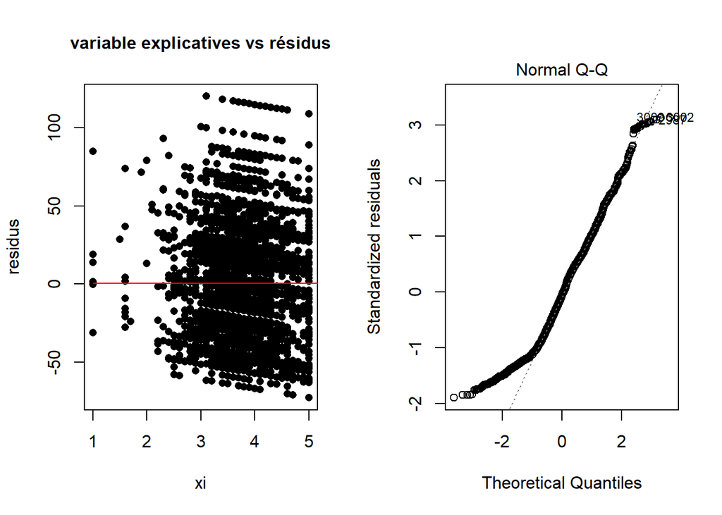

```r
# Graphique de l'hypohthése de normalité

plot(reg,2)
```

```r
### tests statistiques

# Test d'adequation de Rainbow
library(lmtest)
print( raintest(reg) )
```

```
##
##  Rainbow test
##
## data:  reg
## Rain = 1.4056, df1 = 1631, df2 = 1629, p-value = 3.58e-12
```

```r
# Test de normalité de Shapiro-Wilk
print(shapiro.test(e))
```

```
##
##  Shapiro-Wilk normality test
##
## data:  e
## W = 0.96934, p-value < 2.2e-16
```

On constate que le nuage de points démontre une adéquation globale satisfaisante, illustrée par une ligne horizontale centrée autour de 0. Ceci suggère une répartition uniforme des résidus le long de cette ligne, indiquant ainsi l’indépendance des résidus par rapport aux variables explicatives, en accord avec l’hypothèse d’adéquation.

Cependant, la présence de cette ligne horizontale suggère également une faible relation linéaire, suggérant que le modèle linéaire pourrait ne pas être optimal pour expliquer la variation de la variable dépendante en fonction de la variable indépendante. Cette observation corrobore les résultats de notre analyse exploratoire antérieure.

Par ailleurs, le test de Rainbow, avec une p-valeur inférieure à 0,05, suggère le rejet de l’hypothèse de linéarité du modèle de régression linéaire simple. Il indique qu’un modèle de régression non linéaire pourrait mieux s’adapter à nos données, en accord avec notre contexte spécifique.

Noralité

Enfin, il est important de noter que les résidus ne suivent pas une distribution normale. On peut observer une asymétrie dans les extrémités de la distribution, et le test de Shapiro-Wilk renvoie une p-value nulle. Cependant, il convient de souligner que cette hypothèse est la moins contraignante dans le cas d’une estimation des moindres carrés.

Enfin les résidus ne sont pas normalement distribué mais cette hypothése et la moins forte dans le cas d’une estimation des moindres carré.

on préconise le test de Shapiro-Wilk : si p-valeur > 0.05, on admet l’hypothèse de normalité.

**Dire les conséquences**

Il serait judicieux d’explorer plusieurs pistes alternatives :

1. **Modèles de Régression Non Linéaires / Transformation de Variables :** Explorer des formes de modèles plus complexes pour mieux représenter la relation entre les variables.
2. **Modèles de Régression Robuste :** Considérer des modèles plus résistants aux violations des hypothèses classiques.
3. **Modèles d’Apprentissage Automatique :** Investiguer des approches plus avancées en utilisant des algorithmes d’apprentissage automatique pour modéliser la relation complexe.
4. Création de Modèles Prédictifs Impossible entre Ces Deux Variables : Étant donné la faible corrélation entre les variables, il est possible que la création d’un modèle prédictif significatif entre ces deux paramètres soit difficile voire impossible. Dans de telles situations, d’autres approches ou l’exploration de variables supplémentaires peuvent être nécessaires pour obtenir des résultats significatifs.

**2- Hypothèse d’Homoscédasticité**

L’évaluation de l’hypothèse d’homoscédasticité, qui postule une constance des variances des résidus à travers différentes valeurs ajustées, est cruciale dans la validation d’un modèle de régression. Nous allons entreprendre une analyse approfondie de cette hypothèse en utilisant des graphiques informatifs et des tests statistiques pertinents.

**Graphiques de Diagnostic :**

1. **Graphique “Residuals vs Fitted Values” :**
- **Description :** Ce graphique représente directement les résidus en fonction des valeurs ajustées. Chaque point représente une observation et sa position verticale indique le résidu correspondant à la valeur ajustée.
- **Interprétation :** Une dispersion (uniforme) constante des points le long de l’axe horizontal indique une homoscédasticité.
2. **Graphique “Scale-Location” :** le graphique “Scale-Location” peut être considéré comme une version améliorée du graphique “Residuals vs Fitted Values” car il utilise la racine carrée des valeurs absolues des résidus, ce qui peut aider à stabiliser la variance des résidus pour des valeurs ajustées plus élevées.
   - **Description :** Ce graphique représente la racine carrée des valeurs absolues des résidus en fonction des valeurs ajustées (prédictions du modèle).
   - **Interprétation :** Si les points sont répartis de manière uniforme et horizontale le long de l’axe horizontal, cela suggère une homoscédasticité, c’est-à-dire que les variances des résidus sont constantes sur toute la plage des valeurs ajustées.

**Tests Statistiques :**

**Test de Breusch-Pagan :** Le Test de Breusch-Pagan évalue l’hypothèse d’homoscédasticité en considérant si la variance des résidus est constante à travers les différentes valeurs ajustées. La procédure est la suivante :

- **Hypothèse Nulle (H0) :** La variance des résidus est constante (homoscédasticité).
- **Interprétation :** Si la p-valeur associée à la statistique de test est supérieure à un niveau de signification choisi à 0,05, alors on ne rejette pas l’hypothèse nulle et on conclut à l’homoscédasticité.

**Test de White :** Le Test de White est une extension du Test de Breusch-Pagan qui inclut également les termes croisés des variables indépendantes. Cette extension vise à détecter des formes plus complexes d’hétéroscédasticité. La procédure est similaire à celle du Test de Breusch-Pagan :

- **Hypothèse Nulle (H0) :** La variance des résidus est constante (homoscédasticité).
- **Interprétation :** Si la p-valeur associée à la statistique de test est supérieure à un niveau de signification choisi à 0.05, alors on ne rejette pas l’hypothèse nulle et on conclut à l’homoscédasticité.

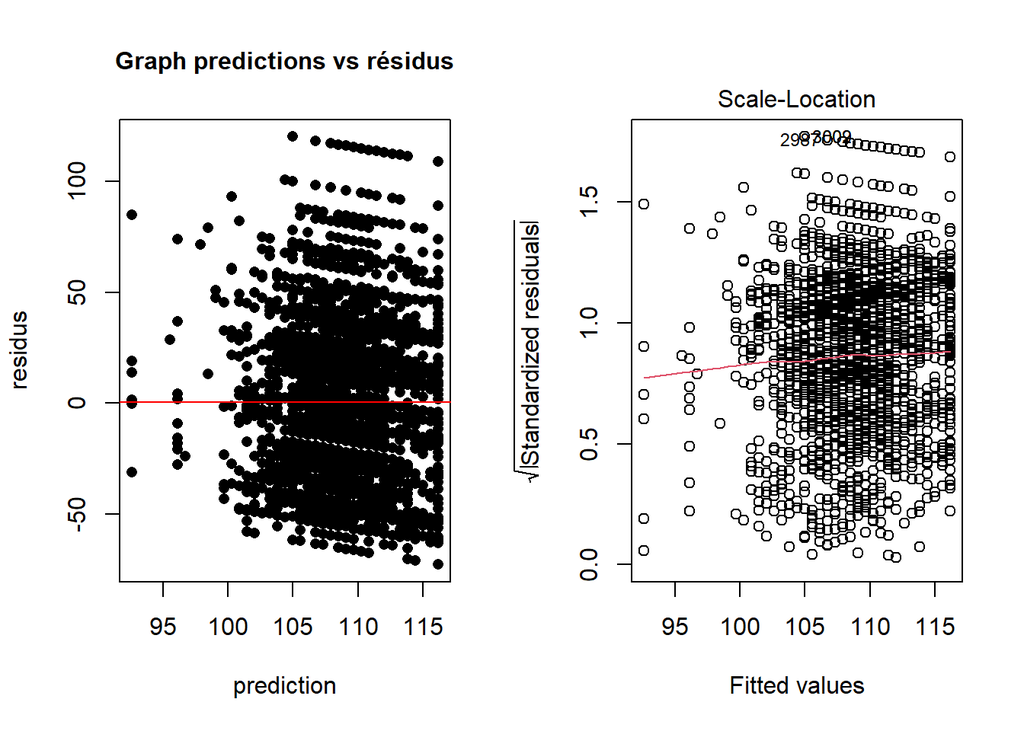

```r
par(mfrow=c(1,2))


prediction=fitted(reg)
plot( prediction, residuals(reg), pch=16, xlab="prediction", ylab="residus", main="Graph predictions vs résidus", cex.main=1)
lines(lowess(rstudent(reg)), col="red" )

# Ce graphique à pour meme but que le premier mais on utilise des résidus standardisé pour les mettres à la meme échelle.
plot(reg,3)
```

```r
# test Breusch-Pagan
print( ncvTest(reg) )
```

```
## Non-constant Variance Score Test
## Variance formula: ~ fitted.values
## Chisquare = 5.301551, Df = 1, p = 0.021306
```

Ce qu’on constate :

**Graphique “Residuals vs Fitted Values” :**

- Aucune structure particulière n’est observée, indiquant une égalité des variances.
- La courbe de régression locale est globalement plate, suggérant une répartition homogène des résidus.

**Graphique “Scale-Location” :**

- La courbe rouge présente une allure ascendante, indiquant une non-homogénéité des résidus.
- L’hétéroscédasticité des résidus est détectée lorsque la variance augmente avec les valeurs prédites.

**Test de Breusch-Pagan :**

- La p-value du test de Breusch-Pagan est inférieure à 0.05, rejetant l’hypothèse d’homogénéité des résidus. La présence d’hétéroscédasticité est confirmée, ce qui peut affecter l’efficacité des estimations.

En conclusion, notre modèle de régression présente des signes de violations de l’homoscédasticité, bien que ces violations puissent être légères. Cela signifie que les variances des résidus ne sont pas strictement constantes et peuvent dépendre des valeurs prédites ou des variables indépendantes.

Voici quelques alternatives possibles pour remédier à cette situation :

1. **Transformation des Variables :** Appliquer des transformations sur la variable cible dans la régression, notamment celles liées aux résidus. Peuvent parfois stabiliser la variance.
2. **Modèles de Régression Robustes :* Utiliser des méthodes robustes à l’hétéroscédasticité, comme les méthodes des moindres carrés pondérés ou les méthodes robustes Huber-White. Ces approches donnent moins de poids aux observations présentant une plus grande variabilité.
3. **Utilisation de Variables Supplémentaires :** Introduire des variables supplémentaires qui peuvent expliquer la variabilité non constante des résidus. Cela pourrait inclure des variables interactives ou des termes quadratiques.
4. **Diagnostic Approfondi pour identifier les causes :**
   - Effectuer des diagnostics approfondis pour comprendre la source spécifique de l’hétéroscédasticité. Il pourrait s’agir de variables manquantes, de données aberrantes ou de structures sous-jacentes non capturées.

Les causes L’hétéroscédasticité des résidus peut avoir plusieurs causes, et son identification peut aider à comprendre ces causes spécifiques. Voici quelques raisons courantes de la violation de l’homoscédasticité :

Hétérogénéité des Variances : Les groupes naturels au sein des données peuvent avoir des variances différentes. Par exemple, si vous regroupez des individus présentant des caractéristiques différentes, cela peut entraîner une hétérogénéité des variances.

Variables Oubliées : Des variables importantes qui influent sur la variance des résidus peuvent avoir été omises du modèle de régression. Ces variables omises peuvent être responsables de l’hétéroscédasticité.

Relation Non Linéaire : Si la relation entre la variable dépendante et les variables indépendantes est non linéaire, cela peut entraîner des variations inégales des résidus le long de la plage des valeurs prédites.

Influence de Variables Particulières : La présence de quelques observations ayant une influence disproportionnée sur la variance des résidus peut provoquer l’hétéroscédasticité. Ces observations sont parfois appelées “points levier” ou “observations influentes”.

Modèle Inapproprié : L’utilisation d’un modèle de régression inapproprié peut conduire à des résidus hétéroscédastiques. Par exemple, un modèle linéaire simple peut ne pas capturer une relation complexe entre les variables.

Données de Comptage ou de Proportion :

Dans le cas de données de comptage ou de proportion, la variance peut être liée à la moyenne de la variable. Des transformations appropriées peuvent être nécessaires.

Distribution Non Normale : Des distributions non normales des résidus peuvent également contribuer à l’hétéroscédasticité.

**2- Independance des residus**

Pour vérifier l’hypothèse d’indépendance des résidus dans le contexte d’une régression linéaire, nous alloons utiliser plusieurs outils graphiques et tests statistiques. Voici quelques-uns d’entre eux :

**Graphique**

1. **Graphique des Résidus vs Ordre d’Observation :** Tracez les résidus en fonction de l’ordre d’observation. S’il n’y a pas de structure apparente dans le graphique, cela suggère une indépendance des résidus.
2. **Graphique des Résidus Autocorrélogramme :** Utilisez un autocorrélogramme des résidus pour identifier toute corrélation sérielle significative entre les résidus successifs. L’absence de motifs significatifs indique une indépendance.
3. **Corrélogramme Partiel (PACF plot) :** Le Corrélogramme Partiel affiche la corrélation partielle entre les résidus à différents retards, en contrôlant les retards intermédiaires. Cela peut aider à détecter des corrélations sérielles spécifiques qui ne sont pas immédiatement évidentes dans l’ACF plot.

**Tests Statistiques :**

**1.Test de Durbin-Watson :** Le test de Durbin-Watson évalue la corrélation sérielle des résidus. Une statistique de test proche de 2 indique une indépendance des résidus. Si la statistique de test est significativement différente de 2, cela peut indiquer la présence de corrélation sérielle, ce qui pourrait nécessiter des ajustements ou des modèles alternatifs. - Hypothèse Nulle (H0) : Absence de corrélation sérielle dans les résidus. - Hypothèse Alternative (H1) : Présence de corrélation sérielle dans les résidus.

**Test de Ljung-Box :** Le test de Ljung-Box évalue l’autocorrélation des résidus sur plusieurs retards. Une p-value élevée suggère une indépendance. Ce test offre une perspective sur la corrélation sérielle à différents retards, aidant ainsi à identifier des patterns qui pourraient ne pas être détectés par le test de Durbin-Watson.

- Hypothèse Nulle (H0) : Absence d’autocorrélation dans les résidus jusqu’à un certain retard.
- Hypothèse Alternative (H1) : Présence d’autocorrélation dans les résidus jusqu’à un certain retard.

Si les p-values sont inférieures au seuil 0,05, on pourrait rejeter l’hypothèse nulle en faveur de l’hypothèse alternative, indiquant la présence de corrélation sérielle dans les résidus.

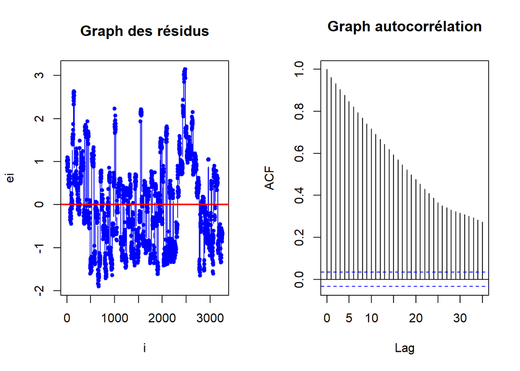

```r
par(mfrow=c(1,2))

plot(rstudent(reg),  pch=20, col="blue", type="b", xlab="i", ylab="ei", main="Graph des résidus")
abline(h=0, col="red", lwd=2)

acf(residuals(reg), main="Graph autocorrélation")
```

```r
# test de Durbin-Watson

print(durbinWatsonTest (reg) )
```

```
##  lag Autocorrelation D-W Statistic p-value
##    1       0.9619999     0.0755562       0
##  Alternative hypothesis: rho != 0
```

En résumé, les résultats indiquent des problèmes importants avec le modèle de régression linéaire simple, suggérant la nécessité d’explorer des alternatives plus complexes pour mieux représenter la relation entre les variables.

Les causes:

L’autocorrélation des résidus dans un modèle de régression peut être causée par plusieurs facteurs. Voici quelques raisons courantes :

1. **Mauvaise Spécification du Modèle :** Si le modèle ne capture pas correctement la structure temporelle ou spatiale des données, cela peut entraîner des résidus corrélés.
2. **Oubli de Variables Importantes :** Des variables pertinentes non incluses dans le modèle peuvent influencer les résidus et causer de l’autocorrélation.
3. **Modèles Non Linéaires :** Lorsqu’une relation sous-jacente entre les variables est non linéaire et que le modèle est linéaire, les résidus peuvent montrer des schémas d’autocorrélation.
4. **Saisonnalité ou Tendances Temporelles :** Si les données présentent des tendances ou des cycles temporels non pris en compte dans le modèle, cela peut conduire à une autocorrélation des résidus.
5. **Erreurs de Mesure ou de Collecte de Données :** Des erreurs systématiques dans la mesure ou la collecte des données peuvent également conduire à des résidus corrélés.
6. **Hétéroscédasticité :** La présence d’hétéroscédasticité, où la variance des résidus n’est pas constante, peut également contribuer à l’autocorrélation.
7. **Dépendance Séquentielle :** Dans le cas de données temporelles, une dépendance séquentielle entre les observations peut entraîner une autocorrélation.

Il est important de diagnostiquer la source de l’autocorrélation pour ajuster correctement le modèle. Des tests statistiques, des graphiques d’autocorrélation, et une compréhension approfondie du domaine sont souvent nécessaires pour identifier la cause sous-jacente.

Ce qui nous améne à la deuxieme partie de notre analyse des résidus verifier les hypthéses du modéle. Pour analyser la structure des résidus nous rajetterons quelques graphiques supplementaire et des tests statisques afin corroborer nos interpretation graphiques.

En effet le graphique des résidus studentisés en fonction d’un indice, nous améne à parler d’une hypothése fondamental du modéle à savoir l’evaluation de l’hypothèse d’indépendance des résidus.

Ce graphique montre comme nous l’avons dit une légère oscillation. Cela peut être dû à une autocorrélation des résidus, donc une mauvaise structure de variance des résidus, qui n’est donc pas diagonale : V(ε) 6= σ2In. Cela peut aussi être dû à une mauvaise modélisation de la moyenne.

Commencons à determiner si il existe une structuration temporelle (autocorrélation des résidus). On rappelle que les résidus sont supposés être non corrélés entre eux (indépendants). Pour étudier l’indépendance des residus on reverra le graphique des residus studentisés (i,ei) i sont les observations et ei les residus, on tracera un corrélogramme qui représente les estimations ponctuelles de la fonction d’autocorrélation (acf), enfin nous finirons par un test Durbin-Watson qui peut être employé pour évaluer la présence d’une auto-corrélation pour un lag de valeur 1. L’hypothèse d’indépendance des résidus est rejetée lorsque la p-value du test est inférieure à 0.05.

Concernant les graph des autocorellation les pointillées horizontaux, sont les intervalles de confiance du coefficient de corrélation égal à 0. Les traits verticaux représentent les coefficients de corrélation entre les résidus de chaque point et ceux des points de la ligne suivante (lag=1), ou ceux séparés de deux lignes (lag=2) etc…

Ici, le plot nous montre qu’une auto-corrélation significative est présente pour tous les lags. De plus le test Durbin-Watson nous indique qu’il existe une auto-corrélation significative entre les résidus d’une ligne du tableau de données et ceux de la ligne suivante.

Cela n’est pas surprenant car dans le graph des résidus on constat de maniere géneral les residus forme des mini groupes entre eux et que les résidus sont corréllés. A noter, toutefois, qu’en présence d’autocorrélation, l’estimateur MCO reste toujours sans biais mais sa variance n’est plus minimale. Le test statistique de student des estimations MCO ne sont pas valides.

A ce stade on peut déja supposé que le modéle n’est pas adpaté aux données choisi, et penser à l’estimateur de la methode des moindre carré genralisé. Il existe de nombreuses raisons qui font que les résidus sont corrélés : mauvaise modélisation, structuration temporelle, structuration spatiale.. Il est cependant diﬃcile, voire impossible, de discerner entre une structuration due à un oubli dans la modélisation de la moyenne et une structuration due à une mauvaise modélisation de la variance .

Dans ce contexte, les résidus ne sont pas indépendants, ce qui viole une des hypothèses fondamentales de la régression linéaire. Cela peut indiquer que le modèle de régression que vous avez utilisé n’est pas adapté aux données ou que d’autres variables importantes n’ont pas été prises en compte dans le modèle.

Pour gérer cette situation, vous pouvez envisager les étapes suivantes :

1. **Considérez un modèle différent** : Si les résidus montrent une autocorrélation significative, il peut être nécessaire de choisir un modèle de régression plus approprié, tel qu’un modèle de séries chronologiques si les données présentent une structure temporelle.
2. **Inclure des variables supplémentaires** : Assurez-vous que toutes les variables pertinentes sont incluses dans votre modèle. Il se peut que des facteurs importants aient été omis, ce qui peut contribuer à l’autocorrélation des résidus.
3. **Transformations des données** : Vous pouvez envisager de transformer les données (par exemple, en prenant des logarithmes) pour réduire l’autocorrélation.
4. **Utilisation de méthodes robustes** : Dans certains cas, des méthodes robustes peuvent être utilisées pour réduire les effets de l’autocorrélation sur les estimations du modèle.
5. **Utilisation de modèles de séries temporelles** : Si l’autocorrélation est liée à une structure temporelle, il peut être nécessaire d’utiliser des modèles de séries temporelles avancés pour modéliser correctement les données.

En résumé, l’autocorrélation significative des résidus suggère que des ajustements sont nécessaires pour que le modèle de régression soit approprié. Il est essentiel d’identifier la cause de cette autocorrélation, que ce soit une structure temporelle ou d’autres variables non incluses, afin de choisir la meilleure approche pour corriger la situation.